# The Society of the Spectacle

### 133

The deified ruling class offers to its subjects a dry, unexplained chronicle of events, which is tied to its mythic history, legitimizing their claim to power. Their intention is to be understood as the earthly execution of the mythic commandments. These chronicles were destined to be transcended and become conscious history,“conscious history”: A direct translation from histoire consciente but here Debords meaning seems limited to the written, recorded, and internalized personal histories of living members of society. but in order for this to occur, a lived-participation of these officially recorded events had to be experienced by a majority of those in society. The resulting participation in these events is a *recognition amongst themselves* as the possessors of a unique present, a period defined by the richness of the events of their own actions, and a home built by their own lived experience. From this participation emerges a general language of *historical communication*. For members of this society, irreversible time truly exists, and within it they discover the memorability of their own history as well as the emergence of a newfound fear of *being forgotten* into the *oblivion* of natural cyclical time. “This is the display of the inquiry of Herodotus of Halicarnassus, so that things done by man not be forgotten in time, and that great and marvelous deeds, some displayed by the Hellenes, some by the barbarians, not lose their glory…”“This is the display of the inquiry of Herodotus of Halicarnassus…”: See Herodotus & Godley, A., 1920.

### 134

To examine history is also, inextricably, to *examine the nature of power*. Ancient Greece was the period when power and the changes resulting from the succession of power was first debated and understood. This occurred under a *democracy of the masters of society*, it was a system diametrically opposed to that of the despotic state—where power settles its accounts only within itself, hidden inside an impenetrable obscurity of internal affairs, by the only means of *palace revolutions* and intrigue. The eventual outcome, either successful, or ending in failure, is outside the realm of discussion and is taken ipso facto. The power shared amongst the Greek community was limited to *spending* a social life, one which existed entirely upon the separate *production* of the slave class—who were not allowed to live autonomous lives, and were kept totally separate. It was only those who do not work, that live.“only those who do not work, that live”: It was only members of the privileged ruling class who participated in events that were recorded into the historical chronicle who ‘lived’. Everyone else was forgotten as mere spectators. The principle of separation amongst the Greek city-states“The principal of separation amongst the Greek city-states…”: See Thucydides. & Smith, C. 1980. defined them internally, but was then focused and expressed externally where it was used to justify the exploitation of foreign cities. Greece had dreamed of a cross-community universal history, but was not able to unify itself in the face of an external enemy. It was not even capable of standardizing a calendar across its constituent cities. In Greece, historical time became apparent and manifest, but was not yet autonomous.“became apparent and manifest… autonomous”: Debord uses the word conscient or “conscious” and opposes it to being “self-conscious” (which I have rendered as “autonomous”), in that a society can be conscious of its own self-development, and its progression through time, but this society was not yet capable of a self-conscious development for its own needs. Thus, he is saying that Greek society was not yet developed to the point where the social bureaucracy reaches such an extent that it autonomously directs society for its own ends; completely separate from the needs of its constituents.

### 135

With the disappearance of the favorable local conditions of the Greek city-states came the collapse of these states, and the regression of western thought, there was no resurgence of the ancient mythical organizations. The subsequent clashes between mediterranean people, and the emergence and collapse of the Roman empire gave rise to *semi-historical religions* that were to become the fundamental building block of a new consciousness of time, as well as new armor for the emerging separate power.

### 136

Monotheistic religions developed a compromise between myth and history, between then hegemonic cyclical time, as it dominated the sphere of agricultural production, and the emerging irreversible historical time—which was the theater of conflict between rulers and realignments between peoples. The religions that developed out of Judaism were the fundamental building blocks universally acknowledged as useful for building new societies based on irreversible historical time. These tools have democratized the ability to create societies, but remain constrained by their own illusions. Time within these societies remains totally oriented to a single final event at the horizon of time—the so-called “Kingdom of God” which is always and perpetually at-hand. These religions grew out of the soil of their own historical time, and have rooted themselves firmly in that place; however, they radically oppose this historical terrafirma as they proclaim their various semi-historical starting points in historical time (e.g. the birth of Christ, the flight of Muhammad“flight of Muhammad”: The Hegira هِجْرَة meaning “departure” is the migration or journey of the Islamic prophet Muhammad and his followers from Mecca to Yathrib, later renamed by him to Medina, in the year 622.). The chronicle that rolls forwards from these beginnings introduce an accumulation mechanism towards the final event—the Islamic conquest of the world, or the increase of capital under the Christianity of the reformation. This accumulation is a religious inversion of thought, one equal but opposite to the *countdown* as time runs out to the Last Judgement; the moment before the advent of the other, true world. Eternity emerged from cyclical time, it was the time beyond cyclical time. Eternity is the force which constrains cyclical time to its irreversible flow, such that it collapses into a *fixed point at times horizon*, where cyclical time has abolished itself. Bossuet said: “and by means of the time that passes, we enter into eternity, which does not pass.”“and by means of the time that passes…” The French bishop and theologian Jacques-Bénigne Lignel Bossuet, for full quote see Bossuet, J. 1872, and Perraud, A. 1891.

### 137

The Middle Ages is an unfinished mythical world until the Last Judgement, whose perfection lays just beyond the horizon—in heaven. It was during this period when cyclical time still dominated production, the first period in which historical time began to erode its foundations. It was during this period where one’s life was measured according to irreversible time, in the form of successive stages of life, with the consideration of life as a *voyage*, as passage without return, in a world whose meaning lies elsewhere. Thus it was during this period when the *pilgrim* was seen as the one who transcended cyclical time, and manifested the symbol of the voyage of life into lived experience. Individuals found the fulfillment of their personal histories within the sphere of power“Individuals found the fulfillment of their personal histories within the sphere of power”: Just as the ruling classes defined themselves by waging war over disputed power, individuals attached their personal historical chronicles to these rulers—thus the knight and his story is entwined with the story of kings.: in the participation in the struggles led by power and in the struggles over disputed power; but the ruler’s irreversible time was shared amongst his people to an infinite degree, all unified to the orientation of the Cristian era (the realization of the Last Judgement)—a world of *armed faith*, where the adventures of the rulers revolve around fealty and disputes over who owes fealty to whom. Feudal society was born out of the merging of “the martial organization of the army during the actual conquest” and “the productive forces of the conquered country”“the martial organization of the army during the actual conquest… / …the productive forces of the conquered country”: See Marx, K. & Engels, F., 1998.—and the factors responsible for utilizing and applying these productive forces is the use and effectiveness of religious language. Under this regime, social domination was divided up into church and state powers, the latter further divided into complex relations of suzerainty and vassalage of territorial tenures or urban communes. Respectively, either those on rural landed estates or as city artisans and merchants. With the collapse of the official orientation of the Medieval world (the Christian Crusades), gradual diversification of personal histories emerged, simultaneously revealing the major unseen contribution of the entire period: the emergence of a cohesive society, propelled by an underlying irreversible historical time, that once-and-for-all obliterated the mythical origins of the past and resulted in a bourgeois class who produces commodities, funds the expansion of cities, and exploits the natural resources of the planet for commercial gain.

### 138

With the waning of the Middle Ages,With “the waning of the Middle Ages”: The title of the 1919 book by Johan Huizinga. See Huizinga, J., 1999. the encroaching hegemony of irreversible time was experienced as a generalized obsession with an aspect of the old order—death. Death of oneself, death of the mythical period. This obsession was brought about by the melancholy of the passing of the mythic world—the last world where the security of the familiar myth could still counterbalance the onslaught of historical time as written by the ruling class. This was a melancholy felt for the inevitability of all earthly things to decay. The great peasant revolts at the end of the Middle Age were a *response to the hegemony of historical time*, a time that was violently wresting the peasantry from their patriarchal sleep formerly imposed by the feudal authorities. These were revolts spurred on by a millenarian utopian vision“millenarian utopian vision”: Millenarianism from Latin millenarius “containing a thousand”, is the recurring belief by many religious, social, or political groups or movements in a coming fundamental transformation of society, after which “all things will be changed”. Millenarianism has existed in various cultures and religions worldwide, with various interpretations of what constitutes a transformation. These movements believe in radical changes to society after a major cataclysm or transformative event. of *creating heaven on earth*, by those who believed the status quo was full of corrupt politicians and only a destructive purge could achieve their vision, thus reviving an ethos that originated from the Christian communities that grew out of the adherents of Judaism—who believed in the Last Judgement and the eventual arrival of the Kingdom of God on earth. These ancient beliefs were the response to the troubles and unhappiness of their times, where announcing the arrival of a new, legitimate king was subversive to the ruling classes of ancient society. Once Christianity developed to the point at which it shared imperial power within the Roman Empire, it officially denounced the hope of achieving Heaven on Earth as mere superstition. This denouncement came from the Augustinian proclamation,Augustinian proclamation: This denouncement came from the theologian and philosopher Saint Augustine of Hippo, who rationalized the sack of Rome by the Visigoths. According to his philosophy, Heaven on Earth is quite literally the Church *itself*, and is the only way to achieve eternity with God in Heaven; a unitary physical space shared with the Catholic Church in Rome. Thus the Church *has become* the kingdom of heaven for itself. This work establishes the idea of the Catholic Church (the City of God) using any means at its disposal, to oppose those governments, political, or ideological movements aligned with the Devil (the City of the World). See Augustine. & Dods, M., 1993. which became the ideological basis of the modern church—that Heaven on Earth had already arrived in-fact. It was nothing less than the Catholic Church in Rome. The peasant social revolts of the millenarians naturally defined themselves as an attempt to destroy that corrupt church. The theoretical problem with the millenarian revolt, however, was that it was revolting purely on the terrain of the historical, and didn’t address or attempt to undermine the church’s mythical basis. In effect, they were trying to rewrite their own history, but one built upon a mythical past they didn’t control, thus corrupting the project at its very foundations. In his book *The Pursuit of the Millennium*,*The Pursuit of the Millennium*, see Cohn, N., 1970. Norman Cohn attempted to demonstrate that the revolutionary movements of the 19<sup>th</sup> and 20<sup>th</sup> centuries were not merely irrational sequels to the religious movements of the crusades, and the religious revolts of the 11<sup>th</sup>, 12<sup>th</sup>, and 13<sup>th</sup> centuries. On the contrary, these revolutionary movements continue to use the false myths of religion as their very conceptual basis, while they struggle to subvert present history to control it for their own aims. What they lack however, is a consciousness that their struggle is *limited to that which is historical* and allows the mythical to remain as unconscious ideology. They fight the battle to control history but aren’t aware of the war to control mythic ideology. The millenarians had to lose because they could not recognize the revolution as their own operation. Their failure was due to actions contingent upon the external sign of “God’s Will” to enable their operation, similar to today’s revolutionary movements which condition their actions upon the decisions of outside leadership. The peasant class was unable to see or understand the workings of society, and their reliance on external validation and leadership prevented any sort of unity in action, nor consciousness of thought. Instead they waged their struggles in the vain attempt to achieve the same tired vision of an earthly paradise.

### 139

With the end of the Middle Age springs forth the Renaissance. This period took possession of the historical chronicle from the ancient world, refuting the religious authority of the Middle Ages and instead establishing both its heritage and legitimacy from the antiquity of the Greeks and Romans. It is a celebratory break from the concept of the eternal Kingdom of Heaven. With it comes an irreversible time defined by an infinite accumulation of knowledge; its historical consciousness is generated-by and written according-to the actions and experiences of its democratic governments and people. With it arrives both the ability to critique and analyze the power of authority vested in the state, and, as shown by Machiavelli,Machiavelli: Nicolo Machiavelli (1469-1527), author of *The Prince* and *The Discourses*, which are early critiques of the power of the state. See Machiavelli, N., Bull, G. & Grafton, A., 2003. an ability to say the formerly unspeakable—state legitimacy is desanctified, not bestowed by God, but by man. In the Italian cities of the Renaissance, the arts and festivals were for the enjoyment of the passage of time, but this enjoyment of transience was transient itself; which Burckhardt considered to be “the very zeitgeist of the era”: as evidenced by his reference to a song by Lorenzo de’ Medici, “How beautiful the spring of life—and how quickly it vanishes.”“How beautiful the spring of life…”: Burckhardt refers to the fleeting nature of the Renaissance period itself along with the enjoyment of transient as emblematic of that period. The quotation is from a song by Lorenzo de’ Medici (1449-1492), an Italian statesman, enthusiastic patron of Renaissance culture, and de facto ruler of the Florentine Republic. See Burckhardt, J., 1914, (Part V, Ch. 8). The song in Italian is:  
Quanto è bella giovinezza  
Che si fugge tuttavia!  
Chi vuol esser lieto sia;  
doman non c’è certezza.  
Roughly:  
“How beautiful the spring of life  
and how quickly it vanishes  
Let whoever wants to be happy, be;  
There is no certainty of tomorrow.”

### 140

The age of kings and monarchs was defined by their tireless struggle to monopolize and determine historical time. It was a transitional period along the way to a complete and total domination of historical time by the bourgeois class, the first class to control irreversible time. The irreversible time of the bourgeoisie is tightly coupled with labor time,“labor time”: see Glossary, “time of production”. they are now liberated from the natural flows and cycles of the seasons as determined by the cyclical time of the peasant classes. As the bourgeoisie gained control over historical time, their labor gradually became *a project to transform historical conditions*. The bourgeoisie was the first ruling class for which labor became a valuable commodity. With the abolition of all social privileges, nobility, and titles, they recognize value only from the exploitation of labor, and have identified the control of the commoditized body of labor as their primary form of capital. Finally, the bourgeoisie recognized the growth of labor-capital as the measure of their own progress. The class that accumulates commodities and capital continually modifies nature by modifying labor itself, by unleashing and controlling its productivity. Up to this time, all official social life had been focused upon the poverty of court life—in the trivial ornamentation and superficial etiquette of banal state administration, whose prestige culminated in the “profession of king”—to whom all individual personal histories had to be sacrificed.“and to whom all individual personal histories had to be sacrificed”: The original French is et toute liberté historique particulière a dû consentir à sa perte or directly “any particular sense of historical freedom had to consent to its loss”. This can be interpreted as literal sacrifices to the king in the form of one’s body: as a soldier in his wars, as sacrifice of crops and wealth in the form of taxes. Can also be interpreted figuratively, as the sacrifice of one’s personal lived experience, since the historical chronicle is only ever written by kings, and laypeople are only passive spectators destined to be forgotten. The era of control over irreversible time by feudal lords ended with the French wars of the Fronde“French wars of the Fronde”: a complex series of social conflicts, revolts and civil wars in France between 1648 and 1653. Debord has variously expressed great interest in the Fronde, and even proposed to make a film about it: *Les aspects ludiques manifestes et latents dans la Fronde* (“Visible and Hidden Playful Aspects in the Fronde”). See Debord, G., 2003. in the 17<sup>th</sup> century, and with the failure in Scotland to put Charles Edward on the throne.“the failure in Scotland to put Charles Edward on the throne”: The failed Jacobite uprising between 1745 and 1746 in support of Charles Edward Stuart (“Bonnie Prince Charlie”). Also known as the Forty-five Rebellion, Charles Edward Stuart led the Jacobite army into England, culminating in the Battle of Culloden in April of 1746, resulting in the end of Jacobitism as a significant political force. The world was about to change its foundations.“The world is about to change its foundations.”: A verse copied from “The Internationale” (French: L’Internationale) a left-wing anthem. It has been a standard of the socialist movement since the late 19<sup>th</sup> century, when the Second International adopted it as its official anthem. The original stanza in French is:  
Foule esclave, debout! debout!  
Le monde va changer de base  
Nous ne sommes rien, soyons tout!  
in English:  
“Enslaved masses, stand up!, stand up!  
The world will change its bedrock  
We are nothing, let us be everything!”

### 141

The victory of the bourgeoisie was a victory of a *profoundly historical time*, a time dominated by an economic form of production which permanently transforms society from the top to the bottom. As long as agriculture remained the primary form of labor, cyclical time continued to constrain social life with *tradition*, which inhibited the development of historical time. The irreversible time of the bourgeois economy is brought to bear upon the remaining vestiges of cyclical time, eradicating it at every encounter across the globe. Historical time, up until the period of the bourgeois revolution, limited participation to individual members of the ruling class. It was initially documented as a mere chronology of cohesive events, generally told as a narrative. Now however; it is understood in its *generalized form*—no longer a series of actions and events of individual rulers, but the inevitable unfolding of events for itself, crushing any individual in its path. The progression of historical time is now a chronology of events of the commodity, time is no longer controlled by the ruling class but by the market imperatives of the commodity. That historical time discovered its foundations in what was previously unconscious—its substantiation in the political economy—but it must remain hidden from the light of day. This directionless trajectory of time, a new fate led by no one“a new fate led by no one”: The original French: une nouvelle fatalité que personne ne domine “a new fate that no one dominates”, is strongly influenced or copied from Lukács, G., 1971 (Pp. 129): “Hitherto it had been that of the blind power of a-fundamentally-irrational fate, the point where the possibility of human knowledge ceased and where absolute transcendence and the realm of faith began”. Essentially, that historical time is no longer the events and chronicles of the ruling class, but an irrational series of events generated by society in an aimless trajectory into an unknowable future. and yet fully influenced by the events of the commodity, is the only thing the market economy has democratized.

### 142

While history is always present as it supports the material and ideological basis of society, it tends to be invisible at the surface of daily life. The victory of irreversible historical time was the beginning of *the time of things*,“the time of things”: Debord uses the phrase en temps des choses, rendered directly into English as “the time of things”, specifically the *objects of mass production* themselves have become the subjects of society, and thus these objects are privileged over social relations and individuals. This is a direct reference to Marx’s concept of commodity fetishism, see glossary. brought about due to the successful deployment of its weapons of mass production, according to the law of the market imperative. The period of the object has democratized *historical time itself* from a scarce luxury accessible only to rulers into a commonly consumed commodity—but as simplified, reduced, and abstracted changing of objects that subjugate all qualitative use of life. This newly democratized historical time is the participation in the chronology of a parade of ever-changing commodity objects, primarily in the individual’s ability to consume these objects. So while cyclical agrarian time had supported an increased participation in the events that defined the period of an individuals lived experience, contemporary irreversible historical time tends to reduce one’s participation in the events that define our lived time.“participation in the events that define our lived time”: rewording of Debord’s concept of “lived time”, originally written as temps vécu, a concise wording of the concept where an individual can directly experience, participate, and contribute to the historical events that define their era. Lived time is opposed to commodity fetishism, see Glossary for “lived time” and “commodity fetishism”.

### 143

The bourgeoisie presented their own irreversible historical time, only to impose it on society while denying *it’s use*. Presented as “once there was history, but not any more”“once there was history, but not any more” This quotation is from *The Poverty of Philosophy*, see Marx, K., 1995. Similar concepts of a history of the perpetual present can also be seen in *The End of History and The Last Man*, see Fukuyama, F. 2006.—time has stopped once they gained control, as the owners of the economy, one tied to *economic history*, they are threatened by any other use of irreversible time which breaks from the historical chronological trajectory they control. The ruling class is made up of *specialists in the ownership of things*, who for that reason are themselves owned by things, their fate bound to the conservation of this reified history, and in doing so assure the permanence of an *unchanging present*. Meanwhile, the workers at the foundation of society are, for the first time, not materially *alienated from participation in history*, since irreversible time has been democratized,“irreversible time has been democratized”: The individual now has the ability to view, buy, and consume commodity objects in the general economy, whereas it was previously limited to a social elite. More concretely, social media allows individuals to participate in history by ‘going viral’, but history quickly moves past these individual moments, as the attention—or gaze of the public—becomes commoditized and buried under the continual Spectacle, and the individual subjects of the ‘viral event’ are quickly subsumed by the global flows of an emergent Spectacular attention economy that expands autonomously according to market imperatives. For more on this see Odell, J., 2019 and Zuboff, S., 2019. and historical events can be generated from those at the foundations of society. The demand to *live* within the historical time which it creates at its foundation, the proletariat discovers the simple, unforgettable core of the entire revolutionary project; although all attempts up to now have been defeated, every attempt signals possible lines of flight for a new historical life.

### 144

The first bourgeoisie to have seized power christened their period of irreversible time after themselves, and assigned it the value of its absolute origin: Year I of the Roman Republic.“Year I of the Roman Republic”: Much like the Roman Republic, the French Revolution revised the calendar to start its chronology from the beginning of the Republic, September 22, 1792. With the rise of Napoleon, it was then reverted to the traditional Roman-Christian calendar in 1806. The Republic blossomed out of the revolutionary ideology of general freedom which had to first destroy the last remnants of its mythical social values and any traditional regulation of society. But the ideology of general freedom had been unable to conceal its underlying will, although draped in Roman clothes“draped in Roman clothes”: Paraphrased from Marx, full quotation “Thus Luther donned the mask of the Apostle Paul, the Revolution of 1789 to 1814 draped itself alternately as the Roman republic and the Roman empire…”, see Marx, K., 2008.—the *freedom of commerce*. Having destroyed the social foundations of traditional society in order to establish its unchallenged rule, this emerging society of the commodity found itself unstable, and had to rebuild the social passivity that came before it, thus “Christianity with its religious cult of man in the abstract was the most fitting form of religion”“Christianity … most fitting form of religion”: Full quotation from Marx, K. Marx, K., Mandel, E., Fowkes, B. & Fernbach, D., 1978 (Ch. 1, Section 4). for the reinstatement of passivity. Thus the bourgeoisie made a compromise with Christianity, one symptom of which is reflected in its presentation of time: the Republic abandoned its own calendar“the Republic abandoned its own calendar”: The Romans used the Coptic calendar (also known as the Alexandrian calendar) which was used by the agrarian populace in Egypt, it was a reform of the ancient Egyptian calendar introduced by Ptolemy III. This calendar was abandoned by the Romans after the reforms of dictator Julius Caesar and Emperor Augustus in the late 1<sup>st</sup> century BC, where it was called the Roman or Julian calendar. In October of 1582, Pope Gregory XIII introduced the Gregorian calendar, which is now the most widely used calendar in the world, officially coupling the Roman chronology with the Christian chronology. and its own conception of irreversible historical time—instead bound to, and extending the chronology of the *Christian era*.

### 145

The development of capitalism entailed the *global unification* of irreversible time. Universal history became a reality, as the whole globe was unified under the development of irreversible time. This is a singular history that progresses the same everywhere at once, amounting to the End of History—a refusal of the progression of any major historical divergence. This appears the world over as a repetition of *the same day*, a uniform and equal amount of time fully allocated to the production of commodities. This is a unified irreversible historical time belonging to the *globalized marketplace*, and thus also the time of the global spectacle.

### 146

The irreversible time of commodity production is primarily the measure of commodities produced.“the measure of commodities produced”: E.g. GDP: Gross Domestic Product. Therefore *the conception of time generalized* across the globe refers only to the time spent laboring to produce commodities, and should only be organized by the specialist interest groups who own the production of those commodities. This conception of time is not general in character, but *merely one particular type of time*.“merely one particular type of time”: Irreversible time attempts to generalize only the time spent laboring, which serves only the interest of capital, but this is a time that is devoid of any social value. Laborers only experience exploitation with the increase in capital, and the increase in measures like GDP are completely divorced from lived experience.

## VI. Spectacular Time

> *“We have nothing that is ours but time, which even those without a roof can enjoy.”*

> —Baltasar Gracian, *The Art of Worldly Wisdom*

### 147

The time of production—commodified time, that time which has been segmented, allocated, where every interval is equivalent in value and therefore indistinguishable. The time of production produces an infinite accumulation of these fungible intervals of time that are equivalent without equality. This effectively renders irreversible time into abstract units, of which each segment must prove on the stopwatch their quantitative equality. These abstracted units of time are, in reality, merely their use-value in *exchangeability*. According to this regime of social-control by commoditized time—“time is everything, man is nothing; at best he is the carcass of time.”“time is everything, man is nothing…”: See Marx, K., 1995 (Ch. 1, Section 2). This is a complete devaluation of time—an inversion of the idea that time is the space in which human society grows and blossoms into the “terrain of human development”.“terrain of human development”: See Marx, K. 2005 (Ch. 13).

### 148

To complement the time of production—the time of human non-development, is *consumable time*. Consumable time is returned to social life as a by-product of the time of production. It is experienced as *pseudo-cyclical time*.

### 149

Pseudo-cyclical time is in fact the time of production *disguised* as time to be consumed freely by the workers. Pseudo-cyclical time exhibits the same characteristics as the time of production, namely equally segmented, fungible units of time; the qualitative dimensions of which are suppressed in favor of quantitative equality. Since this pseudo-cyclical time is a complementary by-product of the time of production, *it must maintain the hegemony and legitimacy of the time of production*“it must maintain the hegemony and legitimacy of the time of production”: This is a significant rewording from the original French, which reads Mais étant le sous-produit de ce temps destiné à l’arriération de la vie quotidienne concrète. This was translated by Knabb as “But as a byproduct of commodified time whose function is to promote and maintain the backwardness of everyday life”. My translation abandons the “backwardness of everyday life” wording used in translations by both Knabb and Nicholson-Smith. I’ve attempted to clarify how the time of production is privileged over the subservient role of pseudo-cyclical time. See Debords’ *Perspectives for Conscious Changes in Everyday Life* for more on the “colonization” of everyday life, see Knabb, K., 2006 (Pp. 90-99). as the colonizer of time itself, in which consumable time is relegated to the subservient role as gift rather than as equal. To maintain these complementary roles, pseudo-cyclical time necessarily finds itself laden with false attributions of value,“false attributions of value”: E.g. That the weekend is more valuable than the weekdays, the general sentiment that Mondays are worse than Fridays. These moments of time are perceived to be more valuable since the worker is able to consume this time freely. and these moments are segmented into a sequence of artificially distinct events, which are merely undifferentiated moments of time perceived to be more highly valuable.

### 150

Pseudo-cyclical time is the contemporary equivalent to the time spent surviving in nature—foraging for food, searching for shelter, but in the contemporary milieu—shopping, chores, and conducting economic transactions. Under both of these regimes, daily life is devoid of decisions, while under pseudo-cyclical time the individual is no longer bound to the natural order, but instead bound to the economic consumerist-nature thus created by alienated labor. Thus, pseudo-cyclical time returns to the same *natural* cyclical rhythms that regulated the survival of pre-industrial societies. It builds upon the vestiges of ancient cyclical time, using it as a foundation and generating new variations: day and night, weekly work and weekend rest, and the cycle of harvest festivals, holidays, and vacations.

### 151

Pseudo-cyclical time is a time that has been *transformed by industry*.“a time that has been transformed by industry”: The way individuals spend consumable time is determined by industries whose sole output is the creation of ever-new consumable entertainments and activities: packaged vacations, films, video games, television series, social media, etc. This time is itself a consumable commodity, one which has combined all aspects of a social life which were previously distinguished: private life, economic life, and political life. This combined consumable time of contemporary society is the raw material to be consumed by the worker how they see fit, but only as input to a set of ever-expanding products on the market of socially controlled schedules. “A product that already exists in a form suitable for consumption may nevertheless serve as raw material for some other product.”“A product that already exists… other product”: C.f. Marx, K., Mandel, E., Fowkes, B. & Fernbach, D., 1978. (Vol. I, Ch. 7, Section 1). As the worker earns more vacation time the longer they stay at a company, this additional time must be then used to consume new films, new television series, and new hobbies that mandate the consumption of new equipment. Thus this “free time” becomes pseudo-cyclical time—a consumable commodity that is the raw material for the generation of new products and commodities.

### 152

In the most developed sectors of concentrated capitalism, the market creates “all inclusive” packaged experiences, which constitutes a single unified commodity, thus increasing the number of diverse commodities. This is made possible by the increase and ubiquity of the services and hospitality economy, the increase of leisure activities, and the “all-inclusive” luxury accomodations with pre-set vacation itineraries. This spectacular form of leisure even extends to socialization as well, with the inclusion of “exciting conversations” and “celebrity meet & greet” events. These types of events would not be taken seriously without a corresponding impoverishment of the realities they parody. Obviously, these commodities reflect the advancement in sales techniques in that they can be bought with credit.

### 153

Consumable pseudo-cyclical time is spectacular time. In the most narrow sense, it is the time allocated to the consumption of images,“time allocated to the consumption of images…”: Debord limits the conception of consumable time to the consumption of images, but his meaning of “images” can be interpreted loosely to include the consumption of films, newspapers and magazines, advertisements in all their forms, video games, social media, and any representative form of consumable media products and services. more broadly it is the conception of time itself as a consumable commodity (a representation of moments of time perceived as having more intrinsic value than the time of production, the so-called “real life” the worker must endure.) This consumable time is increasingly allocated to the consumption of images (images which in turn serve as advertisements for all other commodities), deepening our immersion in the spectacle. This time is the realm of the commodity, and the images are the medium with which these commodities act upon our consciousness most efficiently. This realm is the chosen battlefield from which the spectacular commodity mounts its strongest attack. The ultimate goal of this attack is to maintain our attention upon the spectacle itself, and to increase the time allocated to the consumption of pseudo-cyclical time within the spectacle. This battlefield is at once the locus of the spectacle, the center of its operation, and the most exemplary form of all consumption. The fetishization of time-saving products and services so sought after by contemporary society, whether in the increasing speeds of cars, the speed and convenience of online shopping, pre-made or instant meal replacements,“pre-made or instant meal replacements”: Debord uses the phrase ou de l’usage des potages en sachets or “the use of instant soup”. Most recently there’s been an explosion in home meal delivery kits such as HelloFresh, Blue Apron, and Sun Basket. As for instant meal replacements, look no further than Soylent, the minimalist liquid meal which I myself must admit to drinking. I described my rationale for drinking it in *Hacking Life*: “[Soylent] allows Ron to simplify: to save on time (shopping, cooking, and cleaning), money (it is an inexpensive source of nutrients), and waste (it can keep for weeks).” see Reagle, J., 2019 (Pp. 102). I’m actually drinkng Chocolate Soylent while editing this note because it doesn’t make a mess of my keyboard. Would Debord be ashamed, or would he understand that we’re all continually subject to the Spectacle? and the explosion of “fast-casual” restaurants all contribute to the increased time spent consuming images. In the United States, Americans end up watching television three to six hours per day. The social aspect of consumable time is dominated by moments of leisure and vacations—moments which are presented as fleeting, *exclusive and distant*, therefore desirable by definition, like any spectacular commodity. These moments are simultaneously presented as separate from daily life and yet more exemplary as moments of real authentic experience. These authentic moments are supposed to be looked-forward to, whose cyclical return is to be expected. But it is within these authentic, privileged moments that are supposedly more real than daily life, what is in fact being produced is a more intensified version of the spectacle: a personalized, lived, spectacular event. Thus, what has been portrayed as an authentic life turns out to be merely a life more *authentically spectacular*.

### 154

The contemporary period of spectacular time presents itself as essentially a time made up of many frequently recurring festivals, it is actually a period without festivities. During the period of cyclical time, the festival was a frequent and luxurious experience of communal participation in life, now impossible in a society without communities or luxury. These pseudo-parties, poor parodies of gift exchange and JubileeJubilee: A periodic festival of general debt-forgiveness, and often included the freeing of both slaves and prisoners. See Graeber, D. 2011. typical of festivals of the previous period have been vulgarized into a surplus of expenditure, but this expenditure only results in an expanding amount of disappointment; a disappointment centered upon the promise of the next pseudo-festival, one just as equally sure to disappoint. Under the reign of the spectacle, the lower the use-value (e.g. moments of leisure or pure inactive boredom) placed on time, the more highly cherished this time becomes as it is experienced as a more authentic time of real life. The reality of time has been replaced by the *advertisement* of spectacular time.

### 155

In ancient agricultural societies, the passing of cyclical time was perceived as the passage of their labors in sync with the natural transition of the seasons. In contrast, the consumption of pseudo-cyclical time during the contemporary period of spectacular time is in contradiction with the time of production—which is motionless; its history has reached a stable, unchanging conclusion while pseudo-cyclical time has cycles, and continues to allow change and lets the participants write their *own* history in a linear progression of time. The cyclical time of the agrarian period was motionless with its repetitive illusion of cyclicality, but the events of these cycles were authentically experienced. Spectacular time is the progression of linear time“Spectacular time is the progression of linear time…”: The original French is a beautifully worded example of Debords’ use of détournement, so I’ve included it here: Alors que le temps cyclique était le temps de l’illusion immobile, vécu réellement, le temps spectaculaire est le temps de la réalité qui se transforme, vécu illusoirement., translated as “Whereas cyclical time was the time of unchanging illusion, actually lived; spectacular time is the time of changing reality, lived illusorily.” as changed by the influence of spectacular history, but this history is an illusory experience, one merely witnessed through the media.

### 156

The process of commodity production continually innovates new, cheaper, and more efficient methods to produce the same products. As such, consumption is relegated to the mere repetition of the same products with decreasing costs, and decreasing quality. Under the reign of spectacular time, dead labor dominates living labor,dead labor / living labor: Dead labor is without actual creation: a passive form of rent seeking, control of capital flows and the management of living labor; the labor of the ruling class. Living labor is the labor to reproduce the material basis of everyday life, labor of the working class, and creators; those actually producing services, products, and affects. For more on affective labor, see Hardt, M. & Negri, A., 2000. and the past accumulations of capital continue to dominate the present creation of time and history.“the past accumulations of capital… dominate the present”: Full quote is “In bourgeois society, the past dominates the present; in communist society, the present dominates the past.” See Marx, K., Engels, F. & Jones, G., 2002 (Part 2).

### 157

Historical time lacks the histories of individual human lives. The individual human life is still not historical since its events are not recorded and simplified into a linear narrative. Furthermore, the pseudo-events popularized and dramatized by the spectacle are not actually experienced by the individuals who watch them. In any case, these pseudo-events are immediately made irrelevant by the novelty-generation mechanism inherent to the spectacle. On the other hand, what life events have actually been experienced have no relation to the official irreversible historical time which dominates society. The actual lived experiences of life remain outside the allocation of pseudo-cyclical time (the time legitimated by the time of production.) So while work remains something perceived as ‘apart from life’, and ‘free time’ remains perceived as more authentically real life, the real lived experience of commuting, doing chores, child care, cooking, sleeping, etc, is therefore cut off, as separate from ‘real life’, remaining undocumented and unaccounted from any personal or historical time. This deprives daily life of language and as a formal concept, and it lacks any analysis of what events occurred within its own past, events which have not been communicated. The real time of life is misunderstood, forgotten, undertheorized, and smothered—to the benefit of the fake memories of the spectacle: a memory of the unmemorable.

### 158

The spectacle then, as the reigning system of social organization, is a method for the paralysis of history and memory. The spectacular society has abandoned a history based upon historical events. This is a society with a *false consciousness of time*.

### 159

A prerequisite for the conscription of the working class as “free” producers“free producers”: Free as in liberated to produce and consume as they see fit. Under Spectacular time, the worker is no longer free when they perceive time within the narrow understanding of time alternating between the time of production and consumable time. This is a false dichotomy of course. Their pseudo-free choice is in fact contingent on their time having been stolen in the first place. and consumers of commodity time was the *violent expropriation of that time*. Spectacular time was only possible after this first dispossession of the producer.

### 160

The irreducibly biological element of labor is its natural human cycles: the workers dependence on sleep and waking, health and injury—both attest to the accumulation of irreversible time as the inevitable truth of aging. Contemporary production systems consider these natural and inevitable factors as *secondary* concerns. As such, aging and health are ignored by the economy of capitalist production as externalities that have no bearing on the production of consumable widgets, new inventions, and entertainment. The individual spectator trapped at the center of spectacular society can not experience a conscious sense of life as a journey moving towards fulfillment, or the inevitable march to death. Instead, life remains in stasis, on-hold for the next spectacular event. As such, we who have given up the idea of living will surely never be able to embrace our own death. Life insurance advertisements stake their business strategy on a moral falsehood that claims that it is reprehensible to die without first ensuring the continuation of one’s economic productivity. In *The American Way of Death*,*The American Way of Death* is an allusion to the book about the American funeral industry. See Mitford, J. 1978. death itself is advertised as an inversion, an event that attempts to maintain the *appearance* of life by means of excessive sentimentality, ostentatious displays of wealth, and an overly commercialized industry to support it. Alongside the continual bombardment of advertising, it is forbidden to get old, everyone’s “youth-capital” must be economized, while all models, celebrities and actors remain forever young. Thus, despite our collective efforts to economize youth, it has none of the lasting and cumulative properties of financial capital. The social absence of death is equal to the social absence of life.

### 161

As described by Hegel, time is the *necessary* alienation, as we age we gradually lose our sense of self and discover our true selves. Time is the environment in which we become the other, the thing outside ourselves we didn’t understand, and in becoming other, we become a more fully understood self. The opposite is true of the alienation generated by the spectacle of late capitalism—this is an alienation felt as disenfranchisement from meaningfully participating in the historical events during one’s lifetime. We may spectate but we cannot participate, absolute alienation in the *foreign present*. This is *spatial alienation*, the society that separates the subject from participating in the events of our own time, foreclosing our individual ability to experience self-discovery through aging. The beauties and graces of the naturally alienating process of time has instead been petrified, and the risks of *lived* self-creation and discovery have been eliminated.

### 162

In contrast to the *passing fashions*“passing fashions”: Those trivialities that get the most spectacular attention in the media, but are so often immediately irrelevant soon after. Examples include “issues”-oriented political debate, political scandals and palace intrigues, clothing, diet and food fads, internet memes, television & film, and video game entertainment. that preoccupy pseudo-cyclical time, the *dominant styles* that actually influence the contemporary period are carefully obfuscated and hidden—these can be recognized as the main concerns that will cause revolution if they become apparent and revealed.

### 163

The motion of time exists despite human beings, it is only concretely experienced as moments when society consciously segments and describes time for *human use*. The perception of time for any society is determined by its stage of human labor: under agrarian labor and cyclical time, time is humanized and therefore any individual is able to participate in the historical events of their own time; under economic productive labor and irreversible historical time, the time is dehumanized—the individual cannot meaningfully participate in the lived historical events of their own period. The revolutionary project of realizing a classless society goes along with an inclusive historical life, one in which all people can participate in the events of their own historical period. This project entails the withering away of a singular measure of historical time in favor of a more humane, individualized, and *federated multiplicity of independent times*,“federated multiplicity of independent times”: This project entails the withering away of a unified measure of time, an allusion to the anarchist concept of replacing the nation state with federations of independent communities. This is also a postmodernist perspective on time, in that the abolition of a singular chronicle entails an abolition of grand-metanarratives as well as a unified perspective on “truth”—in favor of a multiplicity of timelines and perspectives which are all equally valid. ones which are playful in nature, where every individual time can interplay and unify on an ad-hoc basis, where all timelines are autonomous, valid, and simultaneously present. A successful realization of this revolutionary project is a generalized, fully conscious conception of time, determined by personal life events which are recorded into a new historical record, a personal chronology that can be flexibly federated into other personal chronicles voluntarily and playfully—a sort of communism that suppresses all spectacular media-driven and universalized histories. This would be a communism that suppresses and “abolishes everything that exists independently of individuals”,“abolishes everything that exists independently of individuals”: C.f. Marx, K. & Engels, F. 1998 (Part 1, Ch. 4, Section 6). In essence, the autonomous spectacle and all forms of autonomous history and power will gradually disappear. in essence, a project to abolish the historical time of kings, the chronicle, the government with their official time and finally to abolish spectacular time.

### 164

The world has already dreamt of such a time“The world already dreams of such a time”: See Marx, K., September 1843.—it has to just wake and remember to really live it.

## VII. The Organization of Territory

> *“Whoever becomes master of a city accustomed to live in freedom and does no destroy it, may reckon on being destroyed by it. For if it should rebel, it can always screen itself under the name of liberty and its ancient laws, which no length of time, nor any benefit conferred will ever cause it to forget; and do what you will, and take what care you may, unless the inhabitants be scattered and dispersed, this name, and the old order of things, will never cease to be remembered…”*

> —Machiavelli, *The Prince*

### 165

Capitalist production has become ubiquitous, all military, political, and trade barriers between societies have been broken down, there is no longer an outside to Capitalism. This is an extensive and intensive process of *trivialization* of unique local customs, traditions, methods, languages, and cultures. These local distinctions are commoditized and *banalized* for consumption by the global market. This created a universal space of the global market, where local goods, cultures and the places themselves are made accessible to the market, each comparable and homogeneous to better conform to the ease of exchange—therefore bankrupt of its once unique character. The corporate restrictions on craft guilds of the Middle Ages assuring the *quality* of craft production had to be destroyed to make way for the era of mass production, just as it had to dissolve the autonomy and quality of *places*.“it had to dissolve the autonomy and quality of places”: This can be seen happening everywhere simultaneously, with the reproduction of the same banal streets, stores, languages, restaurants, styles, and customs across the globe—the “airbnb-ification” of the world. See Chayka, K., 2016. The cheap prices of its commodities are the heavy artillery with which it batters down all Chinese walls.“The cheap prices of its commodities are the heavy artillery with which it batters down all Chinese walls”: From the original French: Cette puissance d’homogénéisation est la grosse artillerie qui a fait tomber toutes les murailles de Chine. This is a direct reference to *The Communist Manifesto*, see Marx, K., Engels, F. & Jones, G. 2002 (Part 1)

### 166

It is in order to become ever more identical to itself, to get as close as possible to unchanging monotony, that the *free space of the commodity* is henceforth at all times modified and reconstructed.

### 167

The spectacular society gradually eliminates geographic distance, it simultaneously replaces it with new internal distances in the form of spectacular separation.“spectacular separation”: Society is making travel more efficient while making places more homogeneous, simultaneously making places irrelevant with technologies such as remote work, video conferencing, and virtual reality—the artificial images used as substitutes for reality itself. These geographic distances are then recreated in the form of spectacular separation—the direct experiences such as community, people, places, events and lives people were previously living are increasingly substituted with ephemeral recreations and cheap copies as our new lived reality, alienating us from directly lived experiences and creating divisions within communities and even families.

### 168

As a by-product of the circulation of consumer goods, tourism, the circulation of people as consumption, is fundamentally reduced to the leisure of going to see what has become banal. The application of business-style management techniques to travel guarantees the *equivalence* of places. The same modernization that has removed time from travel has also removed the reality of place.

### 169

Society has developed its own techniques for the task of molding the natural landscape it finds itself within. UrbanismUrbanism: The French word urbanisme means “city planning” which has an impersonal and bureaucratic connotation. Broadly encompassing urban planning, real-estate development, and gentrification. is capitalism’s direct mode of appropriation of natural and human environments. This capital appropriation gradually evolves towards absolute domination of the environment—in the form of the densely packed urban city. Urbanism continues to expand, eventually remaking the totality of the landscape into its *own elaborately decorated stage*.

### 170

The drive to urbanization is an imperative of capitalism, this drive results in “a freezing of life”.“A freezing of life”: A static world devoid of spontaneity, the result of land development and bureaucratic zoning laws optimized for rent seeking and increased land valuations, devoid of nature—where its residents have no ability to change their surroundings to suit daily life. All desire for change is eliminated in order to serve the profit generating imperative of capital, all autonomy of local residential use is therefore foreclosed, instead privileging real estate development as the only legitimate use. The result of this is a predominance of land organized around the valuable placement of real estate objects over the living use and alteration of land by the very people who live in these spaces, people who wish to change their surroundings over time as use-patterns and ways of living change with the seasons and with time. For more on this see 0xADADA, 2019 (April 16). Described by Hegel as a predominance of “the peaceful coexistence of space”“The peaceful coexistence of space”: This quote has been changed from the original: “The Object thus posited as outside the subject and in its own self as an externality is partly the quiescent side-by-sideness of space, partly a restless becoming in the successive moments of time. Space and time are abstract intuitions or Universal Forms of Intuition.” Quote taken from Hegel, G.W.F., 1986 (Pp. 151 No. 136). over “a restless becoming in successive moments of time.”

### 171

The technical apparatus of the forces of capitalism (television, social media, government policy, and consumer products) should be understood as the tools of separation: grouping people into exclusionary tribes as well as alienating people from their labor and environment—exclusion from participation in daily life. The technical apparatus of urbanization is the fundamental method that makes all others possible—and far more efficient. Urbanization is the creation and preparation of the territory upon which all other technical methods are then deployed. It is the very *technology of separation*.

### 172

Urbanism is the modern method that satisfies the need to safeguard class power. This method preserves the atomization of each worker that the urban conditions of production had dangerously *brought together*. The continual struggle of capital against the organization of the labor force to improve their working conditions has found urbanism to be its most effective field of operation. Ever since the street-by-street battles fought in Paris by the Communards of the French Revolution, those in power have improved their methods of maintaining order on the streets, eventually resulting in the suppression of the streets themselves.“…eventually resulting in the suppression of the streets themselves”: Between 1853 and 1870 the French Emperor Napoleon III commissioned Georges-Eugène Haussmann to destroy the neighborhoods that were the very heart of the French Revolution: namely from the Quartier des Arcis to the Hôtel de Ville, including Île de la Cité, transforming these areas into broad avenues wide enough for an army to march down. In his book *The City in History*, Lewis Mumford describes a “one-way system” whereby “the present means of long-distance mass communication, sprawling isolation has proved an even more effective method of keeping a population under control” (Mumford, L., 1961). This system empowers the ruling class to broadcast their historical perspectives and ideologies to an alienated society who no longer has an ability to respond with its own voice or even amongst each other. Urbanism is the general trend, a global movement to isolation within the crowd, a sense of “*being alone, together*,” but in service to the needs of corporate production—we are isolated to the greatest extent allowable to maximize production and consumption. The greatest examples of how urbanism isolates us together is in the factories, cultural centers (museums, theaters, etc), vacation resorts, and housing developments“vacation resorts, and housing developments”: The planned, gated residential community “Celebration” in Osceola County, Florida which was developed by The Walt Disney Company is an example of a pseudo-community where both vacation and housing developments converge. The community is primarily separated from society by gates, and each household is carefully separated from the others by heavily manicured landscaping—a type of hostile architecture leaving all shared community space to become de facto dead zones of inactivity.—all explicitly oriented to the goal of creating pseudo-community. The dominant imperative of atomizing isolation follows the individual into the family unit, where each member is in their own room, each isolated by their own personalized television, music, and internet entertainment that are so particular to the individual that sharing common entertainment interests becomes increasingly more difficult—and therefore more isolating. The more isolated the individual becomes, the more dominant the images of spectacular society become“The more isolated the individual becomes, the more dominant the images of spectacular society become”: This is to say, the individual is most vulnerable to the dominating one-way conversation of the mass media when they are alone, and unable to relate what they see in the media to their isolated experience of daily life. The increase of media outlets and the explosion of personalized streaming sites like Netflix, Disney+, HBO Max, Hulu, etc, make our television habits increasingly unrelatable (meanwhile experimental television formats like “Bandersnatch” point to the horizon of personalized media in which the actual content of any single episode is personalized for each individual.) For more on how Netflix is transforming personalized media, see 0xADADA, 2021 (January 14) and this is where the spectacle acquires its full potential.

### 173

Prior to the 20<sup>th</sup> century, innovations in architecture were exclusively designed to serve the interests of the ruling class. Now, for the first time, architectural innovations are aimed directly *at the poor*. Architects no longer build ornate, unique places but merely reproduce aesthetically bankrupt habitats characterized by their *mass*: mass-produced for ‘the masses’, dictated by the contemporary conditions of production.

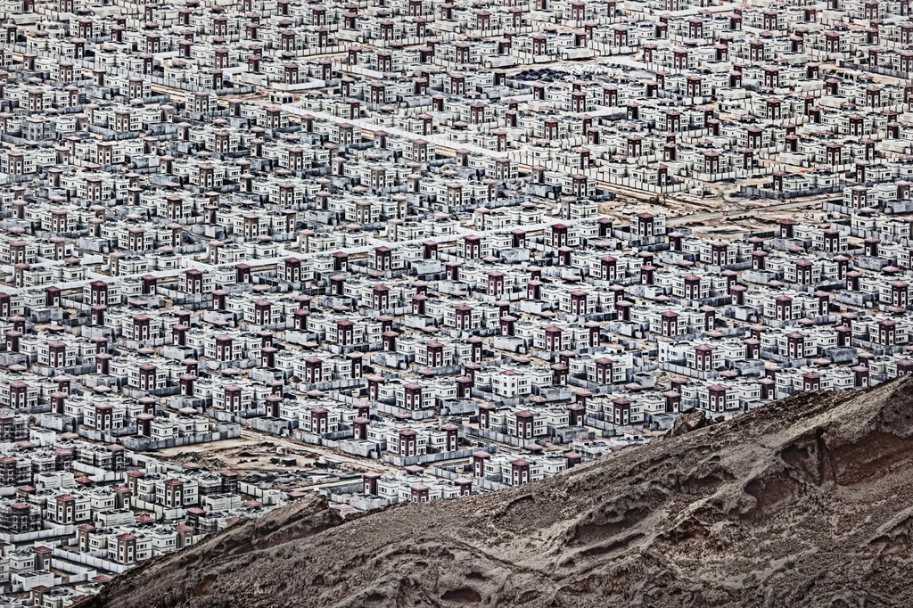

Al Ain City, a new housing development in Mbazzarah Al Khadra, Al Ain, Abu Dhabi, United Arab Emirates. Photo by Andrzej Bochenski. Lodz, Poland.

At the core of these conditions are an *authoritarian decision making process* by which a corporation, driven by the profit imperative, works with the local municipality to abstract a local environment into an interchangeable space of abstraction. This type of architecture develops the same anywhere in the world: the buildings use the same designs and trendy materials no matter where they are, and the same international businesses soon arrive to service the communities (e.g. McDonald’s, Starbucks, etc.) This works especially well in undeveloped countries, which are their most fertile terrain. This process is most efficient when a society’s material power is inversely proportional to its *lack of progress* to appropriate social control of this power. The delay of the conscious appropriation of urbanism corresponds equally with the power of thermonuclear weapons and genetic bioengineering (where genetically engineered human life is already possible.)

### 174

We live in the era of the destruction of the organic urban environment by an urbanism that is exploding the city, littering the countryside with what Lewis Mumford calls “a formless mass of thinly spread semi-urban tissue”.“a formless mass of thinly spread semi-urban tissue”: Quote from Mumford, L., 1961 (Ch. 16.6, Pp. 508). This explosion is exemplified by strip malls, restaurant franchises, and landscapes developed to serve the required efficiencies of automobile-oriented consumption.“landscapes developed only to serve the required efficiencies of automobile-oriented consumption”: For an in-depth analysis on the subject of suburbanization, see Duany, A., Zyberk, E. & Speck, J., 2010. James Howard Kunstler gave an insightful and funny TED talk on the topic called *The ghastly tragedy of the suburbs*, see Kunstler, J. H., 2004. This is the dictatorship of the automobile, where all designs create landscapes to serve vehicles, not animals nor human pedestrians. The automobile, arguably the first example of a product produced during the first stage of commodity abundance, has come to reconfigure the human environment of the city with the dominating imperatives of speed and available parking space to create a centrifugal trend moving gradually away from the city into any nearby countryside with “undeveloped” space. The dominating force of the highway dislocated the historical, organic city centers and instead promoted an ever-growing flat expanse.“an ever-growing flat expanse”: Cities like Los Angeles or Las Vegas are the perfect examples of sprawling automobile oriented cities. Meanwhile, the countryside is developed ad-hoc around temporary “distribution factories”—poor copies of the urban centers of exchange, alienated from the street and the land around them by acres of ample parking space. Even then, these temples of conspicuous consumption themselves become victims of the centrifugal trend of suburban expansion, becoming congested and then likewise abandoned or reconfigured. This gradual process of centrifugal reconfiguration of the urban and suburban environment is the sign that the city is gradually *consuming itself*.

### 175

Economic history has developed upon the presumption of an opposition between the town and the country, creating a race to equilibrium such that a distinction between the two have all but disappeared. The current *paralysis* of historical development, the so-called “End of History” where irreversible historical time refuses to progress“where irreversible historical time refuses to progress”: See commentary on thesis 145.—privileging the development of the independent goals of the spectacular economy, which comes at the expense of all other pursuits. This has resulted in the disappearance of both town and country instead of their *transcendence*. This is most clearly visible as bits and pieces of both urban and rural life are strewn about the landscape, each eroding the other into smooth and undifferentiated zones that are neither urban or rural, but have come to dominate the developed regions of the world.

### 176

The emergent power of the city has made a universal history possible—those events and recorded stories which is accessible to all people. Universal history emerged at the moment the city became predominant and ruled over the country. Marx considered one of the greatest revolutionary merits of the bourgeoisie was that it “subjected the country to the towns”,“subjected the [rule of the] country to the [rule of the] towns”: Quote C.f. Marx, K., Engels, F. & Jones, G., 2002 (Part 1). whose “very air is liberating”.“very air is liberating”: Quote is from the German saying Stadtluft macht frei or “city air liberates” a medieval German saying, expressing how serfs could free themselves from their ties to the landed gentry by escaping to the towns. While the history of the city is also the site for the historical struggle for freedom, it has yet to host its victory. It is also a history of the tyranny of a state administration of both city and country. The city is the *focal point of history* because it is a concentrator of social power, which makes the historical enterprise possible, as well as an awareness of the past, a universal historical consciousness. The present trend of the city consuming itself is a symptom of the spectacular economy retarding the unification of a society of people attaining freedom and a universal historical consciousness—one that will enable society to overcome the totality of its alienation.

### 177

“The country demonstrates just the opposite fact: isolation and separation”“The country demonstrates just the opposite fact: isolation and separation”: see Marx, K. & Engels, F., 1998. (Ch. 1 Part 4, Section 2). (as opposed to the city, which mixes and brings people together). As urbanism consumes the city, it replaces it with a *pseudo-countryside* devoid of any attachment to nature or the social aspects of either traditional farming villages or the mixtures of culture apparent in the organic city have been lost. This new condition of “urban redevelopment”, that densely packed and yet separate and isolated environments produces a new artificial peasantry. These new peasants are molded by their physical conditions and the influence of the spectacle: where once peasants were isolated by physical distance now find architectural separation, and where simple ignorance once reigned, instead reigns the blinding influence of the spectacular image which recreates a simplemindedness in the new peasantry. These forces, both historical and contemporary prevent the peasantry from unifying and taking action in their own best interests, to become conscious of their own responsibility as the creative historical force within society. Peasants in fact create this world, but the lies and artificiality of the spectacle continue to credit the elite; thus to seize control of society and the responsibility for its creation seems just as beyond their reach as it was for those living in an agrarian society to seize control of the natural rhythms and cycles of their labor. The agrarians lived according to a cyclical time controlled by nature, but contemporary pseudo-cyclical time is controlled by society itself. The traditional agrarian peasantry was the basis for the “asiatic mode of production” as exemplified by the Chinese state bureaucracy, a form of “oriental despotism”“oriental despotism”: See Wittfogel, K., 1981. More recently, Žižek has identified a shift from authoritarian despotism to an emergent form of capitalism he calls “Capitalism with Asian Values”. See Žižek , S., 2010. which, because of its wide dispersion across geography, necessitated a heavily centralized bureaucracy. The neo-peasantry, which has emerged from the material conditions of the pseudo-country combined with the mental influence of the spectacle differs from the traditional peasantry in that their simplemindedness, ignorance, and *apathy* to seize power has to be maintained in the present as well as *historically manufactured*. Simple ignorance has been replaced by the organized spectacle of falsehoods.“the organized spectacle of falsehoods”: A rewording of the original French, l’ignorance naturelle a fait place au spectacle organisé de l’erreur or a “natural ignorance has given way to the organized spectacle of error”. The original phrasing was very abstract, I’ve tried to clarify that it is specifically about the lies and exclusions of the media. Late capitalism has reformed education by exclusion, to such an extent that it increasingly moves resources away from history, the arts, health & fitness, and the humanities. Instead, it focuses on STEM subjects and a vocational style of education most well suited to producing a specialized, short lived—and therefore disposable workforce rather than a civic-minded citizenry producing a public good. These “new cities” of pseudo-countryside, the urbanized but consumed cities where the new pseudo-peasantry reside are the clearest symptoms of a complete break from the historical time upon which they were founded. These places continually distance themselves with their own past and create an unchanging continuous present. Their motto may well be: “On this site nothing will ever happen, and *nothing ever has*.” This is all the result, obviously, because the liberation of historical consciousness has not yet occurred in these cities. Instead, we see the uncontrolled proliferation of the force of *historical absence*, which begins to compose its own exclusionary landscape.

### 178

A consciousness of history that threatens the spectacle is to discover the force capable of reappropriating the environment for lived time.“reappropriating the environment for lived time”: The force of a consciousness of history can reintroduce society and individuals to actual lived reality, a reality that enables participation in the events of one’s own contemporary time and makes the local environment conducive to living fully engaged social lives. The proletarian revolution is the *critique of human geography*,“critique of human geography”: See more on human geography: Knabb, K., 2006 (Pp. 1-14, 62-66, 69-73, 86-89). a critique of the environments, and social relationships that individuals are forced to navigate. Through revolutionary acts and events, individuals and communities must construct environments, events, and social relationships to provide the basis of an autonomous control of not only their own labor, but their entire history—thus creating a reality of their own. Revolution opens physical and social space to a new and dynamic mobile space of play, where the rules of play are informal, dynamic and freely chosen.“space of play, where the rules of play are informal, dynamic and freely chosen”: Later in life, Debord formally explored the concept of ‘play’, and most concretely, he and his wife, Alice Becker-Ho, developed a table-top game called Le Jeu de la Guerre or *A Game of War*. Debords’ exploration of play as it applies to his game as well as its revolutionary use against neoliberal capitalism is examined in Barbrook, R. 2014. These open societies liberate authoritarian spaces, and in the process rediscover the previously independent and unique character of places without making them exclusive. This is accomplished without the attachment to the land and agrarian ties to cyclical time, it is an unattached, free space determined by its own egalitarian and parallel historical times, where many chronologies are all available and equally valid. This returns society to an authentic way of experiencing directly lived reality, and thus brings back the authenticity of *travel*, and of life understood as a journey of one’s own creation with its own meaning.

### 179

The most revolutionary idea about urban development hasn’t emerged from urbanism, technology, nor from aesthetics. It is the decision to reconstruct the environment according to the needs of power vested with the workers councils. The environment will be configured by the *anti-state dictatorship* of the proletariat“anti-state dictatorship of the proletariat”: Debord specifically chose the phrase la dictature anti-étatique du prolétariat to cut through the ambiguities of Marx’s dictatorship of the proletariat, implemented by Stalin as a dictatorship *over* the proletariat. His wording makes it very clear that he envisages a distinctly non-state form of social organization.—a generalized and collective form of self-management of aligned individuals working together to create a public good, a “generalized self-management”“generalized self-management”: A Situationist term for the form of self-governance elsewhere called the “anti-state dictatorship of the proletariat”. See Raoul Vaneigem’s *Notice to the Civilized Concerning Generalized Self-Management* in Knabb, K., 2006 (Pp. 363-371). according to the needs of the collective. The power of the workers councils can only be realized and effective if it has the ambition to transform the totality of existing conditions. It cannot assign itself trivial reformist policy or any lesser task than the total transformation of existing conditions if it is to be recognized and *to recognize itself* in a world of its own making.

## VIII. Negation and Consumption in the Cultural Sphere

> *“Do you really believe that these Germans will make a political revolution in our lifetime? My friend, that is just wishful thinking… Let us judge Germany on the basis of its present history—and surely you are not going to object that all its history is falsified, or that all its present public life does not reflect the actual state of the people? Read whatever newspapers you please and you cannot fail to be convinced that we never stop (and you must concede that the censorship prevents no one from stopping) celebrating the freedom and national happiness that we enjoy.”*

> —Ruge,Arnold Ruge: German philosopher and political writer glibly dismissed the idea of a revolution in his letter to Marx, it was only five years later when the Germans revolted in 1848, resulting in the Marzrevolution of 1848-1849. This quote appeared in *The Situationist International No. 12*, with this quote “Five years later that revolution had come. As an amusing example of a type of historical unconsciousness constantly produced by similar causes and always contradicted by similar results”. See *The Beginning of an Era* Knabb, K., 2006 (Pp. 288). *Letter to Marx, March 1843*

### 180

Culture, in a historical society divided into classes, is the sphere of ephemeral knowledge shared in common amongst living individuals, that is to say, it is that power of generalization which *exists independently* and autonomous to itself, as a division of intellectual labor“a division of intellectual labor”: The development of historical society from its roots as a society of myth to the agrarian cyclical society is a shift from one based upon an oral history integrated and entwined with lived experience as one in the same, to a historical society which has separated written chronology from lived experience, which is represented as culture. and intellectual labor of division. A society in which culture is detached from history, a development beyond the agrarian society of a unified mythical culture-and-history is, according to Hegel, “when human life lost its unifying power"when human life lost its unifying power…": What was lost with the ancient Greek oral traditions were the regular occurrence of mortals interacting with Gods. With the gradual decline of the Greek mythic society, we see a corresponding rise in the Greek philosophical tradition. Debord reworded this quote originally by Hegel: "When the power of synthesis vanishes from the lives of men and when the antitheses have lost their vital relation and their power of interaction and gain independence, it is then that philosophy becomes a felt need." See Hegel, G. & Guth., 2013. This line by Hegel is also quoted by Georg Lukács, *History & Class Consciousness*, see Lukács, G., 1971. and when opposites lost their living connections and interactions and became autonomous.” When culture gains independence from history, it then can embark upon an imperialistic drive to make itself predominant (over history.) This drive gradually undermines cultures’ own historical basis and eventually negates itself, destroying this independence. The history that creates the relative autonomy of culture, and the ideological illusions about this autonomy, is also expressed as the history of culture. The history of culture can be read as the gradual negation of culture, a triumphant march towards cultures self-destruction. Culture is society’s intellectual labor to search for the loss of society’s unification of history and culture. In the course of this search, culture as a sphere separate from history is destined to negate itself.

### 181

The struggle between tradition and innovation, which is the principle of the internal development of the culture of historical societies, can only be sustained through the permanent victory of innovation. And yet, cultural development is carried forth by the total movement of history. When history discovers the self-encompassing totality of its own role in culture, it tends to both ignore the importance and impact of the role of culture to society, and assert itself as the totalizing force towards a suppression of all alternatives.“a suppression of all alternatives”: The original French is la suppression de toute séparation but I’ve translated to clarify its meaning as a suppression of all alternatives to the total dominance of the time of production. This has the effect of solidifying cultural aspects of society as implicit truth—ideology. This freezes the historical society into a specific ideological period. This is the mechanism Debord was alluding to in chapter VI. Spectacular Time, where he says “the time of production—which is motionless; its history has reached a stable, unchanging conclusion” (see thesis 155). In this case the ideology of the contemporary period is the “time of production”: an unchanging fact, society can change in superficial (e.g. cultural) ways, but the time of production is a fixed and permanent condition.

### 182

The explosion of society’s general body of knowledge, which contains the understanding of history as the heart of culture, becoming an irreversible self-knowledge, which is expressed by the destruction of God.“the destruction of God”: The society’s mythic past is viewed as a mere fictional narrative, and with it is the fiction of a God that previously formed its foundations. As Marx said in his *Introduction to a critique of Hegel’s Philosophy of Right*: “The critique of religion is the essential precondition for all criticism”.“The critique of religion is the essential precondition for all criticism”: See Marx, K. 1844. The critique that begins with the negation of religion and therefore God is also the critique that continues forever.“the critique that continues forever”: The society founded upon a critique without end becomes the basis of its self-perpetuating ideology. Without the constraints of religion, there is no longer a coherent set of rules to live by, and the lived reality of culture forces this culture to its own dissolution. Like philosophy, once it gains autonomy from the shackles of history—is bound to collapse, any single (non-integrated) discipline becomes autonomous and attempts to account for all of society with its own methodologies even within its narrow field of study. The *lack of total rationality* in favor of a narrow focus dooms these separate disciplines to obsolescence—or to have limited use because the wider integrated social sphere will always demand a cohesive understanding of both culture and history; which the specialized field alone cannot deliver.

### 183

Culture—the knowledge of lived experience shared amongst contemporary society, grew out from the historical chronology that was the dissolution of the mythic society. Culture however, has not become a fully separate discipline—it exists as a subset of, and tied to the sphere of history, with unique aspects limited to the domain of techniques of living daily life and efficient modes of communication. Culture makes up only a partial understanding of daily life“Culture makes up only a partial understanding of daily life …”: Especially considering how alienation prevents everyone from equal access to participation in the daily events which define their period. within a society that is only *partially historical*. In this sense, culture only explains a small subset of historicized society. It remains the meaning in an insufficiently meaningful world.“It remains the meaning in an insufficiently meaningful world.”: Rewording of Marx: “Religion is the sigh of the oppressed, the heart of a heartless world, the spirit of spiritless conditions.” See Marx, K., 1844.

### 184

The end of the history of culture manifests when it is most frozen and unable to develop in time. This occurs in two opposing forms: the development of culture as a specific domain of study that attempts to transcend history, and the maintenance of this culture,“the maintenance of this culture”: The second form of the end of the history of culture is visible with Hollywood’s continual remaking and rebooting of existing film franchises, the cycling of clothing fashions, and the reemergence of old traditions as new trends (e.g. stoicism, the paleo diet, etc.) These repeating patterns are taken up for reexamination by spectacular society and generate new spectacular images to promote the old as new again. In this process, culture superficially cycles but ultimately remains stagnant and continues to distract the proletariat from any real social critique. ossifying it and re-presenting it for spectacular contemplation. In this process, culture cycles through time but remains ultimately frozen. The first form has linked its fate to social criticism, and the second form defends the power of the ruling class.

### 185

Each of the opposing forms of the end of culture exists under a unitary field, within the domains of knowledge and the domains of sensory representation (which was generally considered *art* in historical societies.) The first form holds an opposition between the domain of knowledge and the theory of praxis. The domain of knowledge produces an ever growing accumulation of fragmented specializations. Each specialization eventually negates itself when the *endorsement* of the existing conditions of capitalism forces it to *renounce the knowledge* that built its foundations. This is opposed to the theory of praxis, which alone contains the integrated truth by the secret of its use.“integrated truth by the secret of its use”: Lived practice has the advantage of access to *all* knowledge, integrated. This includes the specialized set of domain-specific knowledge, integrated knowledge, *and* access to the practical techniques of their use. The second form, the domain of sensory representations, privileges an opposition between the critical self-destruction of *common language*—the actual ways of living and experiencing daily life as outmoded, versus the artificial necessity of “new” or “improved” ways of experiencing non-life within the commodity spectacle.“non-life within the commodity spectacle”: In privileging these “improved” illusions of the experience of daily life, the spectacle manages to recreate an artificial recomposition of daily life, assembled from a hodgepodge of traditions and past trends, but with a façade of novelty. This task is primarily accomplished within the realm of the media through the representation of this false novelty with its regeneration of the same images. This is a continually lower-fidelity copy of what was formerly considered life, thus an illusory representation of non-life.

### 186

The mythic culture of agrarian societies provided the reference points for a common language which bound these communities together with grounded truths.“a common language which bound these communities together with grounded truths”: In order for any language to be able to communicate shared concepts, the symbols used to represent these concepts must reference other shared concepts; if the referents are lost, the communication breaks down, and the language is no longer shared in common, as that which were formerly shared references now point to different semantic concepts. Once society loses these myths, they lose the reference points upon which their shared language is based, thus communication gradually breaks down, bringing community along with it. This process continues until a subsequent historical society is able to replace these once common *mythical* referents with *historical* referents. With this replacement completed, a shared language based on historical referents can emerge with its newly formed historical society. Art in the mythical society is the representation of myth itself, in a unified sense that is equally part of daily life and history—living myth. Art in the historical society is an aspect of culture, the *representation* of daily life, but separate from history.“Art in the historical society is an aspect of culture, the representation of daily life, but separate from history”: Art is not part of the officially recorded events of history as inscribed by those in the administration of power. Art, in the contemporary sense, is thus independent of history, is focused on the creation of works which represent the culture of daily life within a historical society. Initially emerging from its use in the religious sphere, this limited discipline similarly follows the same course of eventual self-negation as other specialized domains (as described in thesis 185). Thus, art’s declaration of independence as a total perspective for social introspection smuggles in its own inadequacy for the realization of an integrated analysis of both historical and cultural society using tools that are merely cultural. This is to say, art attempts to describe the totality of reality with a specialized set of tools domming itself to its own self-negation.

### 187

The *positive* significance of postmodernism, that decomposition movement which is the formal annihilation of all art as a separate sphere of discourse, is the loss of a common language“the loss of a common language”: Each discipline of study is busy redefining terminology such that individuals outside these specialized spheres of linguistic practice are unable to understand the ongoing discourse, and a highly specific language is privileged to the point where communication both within and without the field is incomprehensible. The privileging of the destruction of common language is an indication of decay, eventually resulting in the self-negation of the independent discipline. of general communication. The *negative* significance of this loss is that a multitude of common languages remains to be found. Historical societies at least had the unifying and generalizing properties of a common language understood to all, and the art of that period can be characterized by an accessibility with respect to their common language. That said, this common language was limited to the *belated* announcement *to others* about what had been experienced without any real dialog. Contemporary society, on the other hand, is without a common language, each discipline speaking only to itself, unable to speak to wider society and admitting this lack of dialog as acceptable and inevitable. The problem we must undertake is to repurpose language through the participatory activity of practice, creating a community using common language to articulate all disciplines involved in the experience of daily life. The playful ways contemporary poets and artists have reappropriated language to derive new meaning within their artistic works can be broadened to exist simultaneously inside their works and outside—to include all of contemporary society, and thus possess the community of universal discourse and play with time that up till now was merely *represented* by poetic and artistic works.

### 188

When art achieves independence, it represents reality with a flourish of color, describing it more beautifully than reality itself. It is at that moment when reality seems old and grey, a poor substitute for the hyperreality of the art itself.“a poor substitute for the hyperreality of the art itself”: The original French did not mention hyperreality, it reads un moment de la vie a vieilli, et il ne se laisse pas rajeunir avec des couleurs éclatantes or “a moment of life has aged, and it does not let itself be rejuvenated with bright colors”. Debord describes art as more real than reality itself, which influenced Baudrillard. For more on hyperreality, see thesis 192, see also Baudrillard, J., 1994. Reality can no longer be perceived in its full beauty or rich color, its original beauty is available only in memory or nostalgia. The greatness of art appears at the dusk of life.“The greatness of art appears at the dusk of life”: The French here is: La grandeur de l’art ne commence à paraître qu’à la retombée de la vie. is seemingly inspired by Hegel: “When philosophy paints its grey in grey, a shape of life has grown, and it cannot be rejuvenated, but only reorganized, but the grey in grey of philosophy; the owl of Minerva begins its flight only with the onset of dusk.” See Hegel, G., Wood, A. & Nisbet, H., 1991 (Pp. 22).

### 189

The *baroque* periodThe Baroque period: From the early 17<sup>th</sup> to the middle of the 18<sup>th</sup> century. of the arts was the first period in which the historical time created by the ruling classes was able to express itself as a predominant influence in the discipline of the arts. With the beginning of the Enlightenment, the christian world and its explanation of reality was challenged by science, rationality, lutheranism, and the protestants. The christian world had suddenly lost its unified center, the last remaining vestiges of the mythical society which had emerged from the Roman Empire finally lost its singular grasp on society, which it had held during the Middle Ages. This was the collapse of the power of a mythical order founded in Heaven and Earth. The art of the baroque period is *the art of change*, it embodied the change of its times, it captured the ephemeral power and moralities it recognized as they shifted from a mythic modality to a historic modality. As Eugeio D’Ors put it, art during the baroque period chose “life instead of eternity”.“life instead of eternity”: This is to say, art privileged reality in the here and now, embracing the beauty of ephemerality over the promise of an eternal place in Heaven. See Ors., Valéry, A. & Dassas, F., 2000. This work has not yet been translated into English. The outstanding achievements of art during the baroque period were in theater and the festival, as well as the theatrical festival,theatrical festival: The festival was singing, dancing, building, decorating, beauty pageantry, athletics in which the participants not only accomplished the acts but became spectacles themselves—and to others, their equals and fellow citizens, who had done just the same activities. The festival is the exact opposite of the culture of celebrity, in which one merely spectates and has no ability to participate or even engage with the events of daily life. For more on the theatrical festival, see Graeber, D. 2011. a temporary (and ephemeral) constructed space in which all artistic symbolism and reference were self-contained and self-referential, thus creating a common language accessible to all within this space. The theatrical festival creates a unified space operating as *passage* to a cohesive experience away from the disorder occurring in greater society at that time. Contemporary discourse on the topic of aesthetics often places excessive importance on the concept of the baroque, and yet this is a symptom of a growing awareness that a rejuvenation of the classical period of antiquity is impossible in a contemporary social context. Instead, the last three centuries witnessed attempts to establish brief, artificial, and limited artistic projects imitating the superficial aspects of classicism: worship of virtue, a return to family values, etc. These attempts always promote the authority of the moment, either the nobility, the political class, or even a revolutionary vanguard; these moments are merely a promotion of the status quo dressed in Roman togas. Once the baroque moment had run its course, subsequent artistic movements advanced as a procession of ever more individualistic arts of negation, which, from Romanticism to Cubism, each renewing their assault on the common language of previous movements and symbols, as well as history itself, until the complete destruction of the sphere of art. This disappearance of an art representing history is indicative of a ruling elite who no longer communicates using history; history had become independent of the ruling class. At the end of the baroque period, the social basis of the elite aristocracy was limited to a playful expenditure of their own wealth; meanwhile, capitalism had appeared to usurp their power with a new form of class power (the bourgeoisie) bereft of the hereditary and ideological basis with which the elite aristocracy was laden. This new power whose foundations were the simple management of the economy, ushered in a period with no human *mastery*, but a new elite in the form of pure capital. The baroque orchestra, an example of long-lost comprehensive artistic unity, which has long been missing from contemporary artistic *creativity*, has in some sense, been revived in the contemporary *consumption* of the totality of past art. As all of the artistic works of the past become accessible for consumption, only recontextualized, stripped of the original context in which it was created, reinterpreted for consumption in a contemporary historical context. This transforms art specific to a time and place with a specific reflection of its own historical reality into a generalized, universalized “global art”: one devoid of any representation of time, place, or context. Much like how art in the baroque period reflected an elite historical chronology of its period, global art becomes an even more abstracted edifice, a new baroque for the contemporary period. Into this edifice all art is melded, both integrating past and contemporary art forms into a single artistic orchestra, in which the art of all ages and societies can be accepted together, a unified “recollection of memories”, signalling the *end of the world of art*. This is now the age of museums, when no artistic communication can exist, where all art is destined to become relevant *only* to its continually renewed contemporary context, and its originally intended context, referents, symbolism, and communication are abolished. Whatever particular communication problems past works of art may have had are eclipsed by all the present-day obstacles to communication *in general*.

### 190

Art in contemporary society is experiencing its own dissolution, a movement focused on its own self-negation“Art in contemporary society is experiencing its own dissolution, a movement focused on its own self-negation”: The Situationists explored the concept of art as an exploration of its own negation, see Knabb, K., 2006 (Pp. 183-188, 393-397). within a historical society where the common person does not participate in the events of daily life. Art yet strives to describe and reflect upon a chronology it is too specialized to adequately explain. Art ends up representing the attempt to achieve change, but merely succeeds in showcasing its inability to do as such, thus revealing the impossibility of change. The more grandiose its ambition, the further its realization lies beyond. This art is necessarily *avant-garde*, and *it is not*. It is avant-garde in its own disappearance.

### 191

Dadaism and Surrealism“Dadaism and Surrealism”: Dadaism rejected the rationality and the logic of capitalism, instead embracing an anti-bourgeois stance of nonsense. The surrealists embraced science to further its goals of free artistic expression, not necessarily rejecting the ideals of the past, but free of the constraints of reason and embracing the omnipotence of thought. were two art movements that proclaimed the end of Modern art. Historically and ideologically opposed to one another but only partially conscious of the other, these two movements were contemporaries of the last great assault of the proletariat revolutionary movement, the defeat of which left both movements trapped and immobile inside the victorious social sphere of Modernity—the very same sphere these movements had opposed and had declared as dead and buried. The defeat of the revolution sealed the fate of these artistic movements within the sarcophagus of Modernity. Dadaism and Surrealism and bound to one another by their most radical contribution to the sphere of art—their opposition to the ideological critique of the other. This opposition revealed the insufficiency of their critique, each too one-sided and narrow in scope to provide an adequate and total critique of society. Dadaism sought to *abolish art without realizing it*“Dadaism sought to abolish art without realizing it; Surrealism sought to realize art without abolishing it.”: C.f. Hegel, G., Wood, A. & Nisbet, H., 1991: “Philosophy cannot be realized without abolishing the proletariat, and the proletariat cannot be abolished without realizing philosophy.”; Surrealism sought to *realize art without abolishing* it. The critical position elaborated since then by the *Situationists*“The critical position elaborated since then by the Situationists…: see more on the Situationists on art see Knabb, K., 2006 (Pp. 27-30, 224). This is the only use of the word”the Situationists" in this work, as Debord noted in Sanguinetti, G., McHale, J. & Debord, G., 2003. has shown that the suppression and realization of art are inseparable aspects of the same *transcendence of art*.

### 192

The spectacular society produces a tendency to consume the art and cultures of the past, recontextualizing it with contemporary language to be relevant to the present and yet stripped of its original meaning, its symbolism, and its referents—leaving only a congealed mass of superficially artistic form, bankrupt of any communicative or emotional qualities. This consumption is not discerning, it captures both positive and negative aspects of culture. This consuming power is the representative voice of the spectacle in its most expressive form: the *communication of the incommunicable*, or speech without meaning for the sake of speaking. In this social environment we see flagrant attack on language and the use of certain words as having a positive value by the ruling authorities as its use results in the maintenance of the status quo. The horizon of this state of affairs is a language that is celebrated for its total absence of communicative power. The true nature of the attacks on communicative language is concealed when examining the creative expression of contemporary art and poetry, since the primary function of the spectacle is to *bury historical memory under the weight of decontextualized and non-communicative cultural artifacts*,“decontextualized and non-communicative cultural artifacts”: Baudrillard’s later concept of hyperreality and “the copy without original” draws upon Debords conception of the Spectacle: appropriating history in order to generate pseudo-cultural artifacts based upon the original but abstracted from it. See Baudrillard, J., 1994. An additional pointer to the concept of hyperreality is also in thesis 198 where Debord directly references Boorstin’s book *The Image*, which elaborates on the concept in detail, see Boorstin, D., 1992. This concept is also relevant to Deleuze & Guattari with their concept of deterritorialization, see Deleuze, G. & Guattari, F., 1987. thus the artistic referents located within art and poetry remain hidden. These cultural artifacts are continually presented as a parade of new and novel innovations, but are only recontextualizations of artifacts from the past, yet stripped of communicative value. This is a society of pseudo-novelty that continues to use a Modernist ideology and methods that make up its fundamental core. This is a strategy used in such disciplines as “neoliterature” which blatantly admits that it merely contemplates the written word for its own sake,“neoliterature which admits that it merely contemplates the written word for its own sake”: Another example is how so much postmodern film uses the breaking of the fourth wall to involve the viewer as a participant in the action, and yet Shakespeare had used this technique long before, and yet it is presented as a novel innovation. and yet acts as if this were a new approach. So while the contemporary movement celebrates the death of a universal common language as beautiful in its own right, it simultaneously executes its most atomizing practice against a generalized organization of a common society: the application of a “globalized” homogeneity onto all cultures worldwide. This approach seeks to establish the same commercial brands and “experiences” worldwide, a universal hegemonic order of the corporate global village.“global village”: Another proponent of hyperreality, Marshall McLuhan coined the term “global village”; understood as a global coexistence altered by transnational commerce, migration, and culture. See McLuhan, M. & Lapham, L., 1994. McLuhan was also an influence on Baudrillard’s conception of hyperreality. This results in a hodgepodge of decomposed capitalist values, marketing arts, and hegemonic “neo-artistic” aesthetics—creating a flat and banal experience of recomposed pseudo-life, applied everywhere simultaneously.“a flat and banal experience of real life, everywhere simultaneously”: It is now possible to hang out in the same coffeeshops in any major city worldwide, taste the same flavors, listen to the same music, and see the same art on the walls. You are everywhere and yet nowhere. See Chayka, K. 2016. This recomposed hodgepodge of “orchestral works” is most visible in the architecture and urban planning“This recomposed hodgepodge of ‘orchestral works’ is most visible in the architecture and urban planning”: An example of how the spectacle seeks to create “integrated spaces” where artists, software engineers, and workers exist side-by-side and yet their specialized languages make universal communication impossible. These workers become isolated, together; an aggregate of unmixed elements. of the spectacle. The hodgepodge is the product of the spectacle: to recreate the formerly fragmented worker into a form more ideal to the efficiencies required under late-capitalism—“a personality well integrated into the group”“a personality well integrated into the group”: A reference to Riesman, D., Glazer, N., Denney, R. & Gitlin, T., 2001. See Whyte, W., 2002. an increasing trend described by American sociologists Riesman and Whyte. Ultimately the project of late-capitalism is the same everywhere: to *reorganize society without community*.

### 193

Once culture becomes commodified, it must become the flagship commodity in the society of the spectacle. Clark Kerr, in *The Uses of the University**The Uses of the University*: Debord is quoting Kerr, full quote is “The production, distribution, and consumption of ‘knowledge’ in all its forms is said to account for 29 percent of gross national product according to Fritz Machlup’s calculations”, see Kerr, C., 2001 (Pp 66). who studied the trends of the knowledge industry stated that the industry of production, distribution, and consumption of *knowledge* was already 29% of annual gross-domestic product in the United States. He predicted that the second half of the 20<sup>th</sup> century would be driven by the knowledge industry, similar to how automotive drove the first half, and the railroads drove the last half of the 19<sup>th</sup> century.

### 194

The advancement of increasingly specialized fields of academic study result in the destruction of common language and evolves into *spectacular thought*, thinking that must justify a society without justifications. Spectacular thought invades knowledge and culture because the spectacle funds only those fields of discourse that either legitimize the status quo or refuses to investigate the material basis that constitutes spectacular society. Discourse that doesn’t defend the status quo will not be taken seriously.“Discourse that doesn’t defend the status quo will not be taken seriously”: Debord doesn’t say this in thesis 194, but says as much elsewhere in the text; as it is relevant here, I have taken the liberty to include it in the hope that it clarifies his position. This leaves only a general science of false consciousness, a pseudo-science that can never, and will never seriously investigate the material basis of the spectacular system.

### 195

Spectacular thought, the officially funded lies that legitimate spectacular society, act to obscure the actual organization of society around the lies and images they promote: *subcommuncation*—a language without meaning. The discourse within spectacular thought does not know that “conflict is at the origin of everything in its world”.“conflict is at the origin of everything in its world”: C.f. Heraclitus: “Conflict is the origin of all things.” Debord uses Heraclitus but simultaneously points towards Hegel, in which the world is fundamentally made and continually remade by the balancing of oppositional forces through conflict and resolution, thesis & antithesis in order to reach its state of balance—synthesis; the dialectic. In thesis 196 Debord directly attacks the non-dialectical criticism of spectacular thought and his position is that Spectacular thought is not aware that it is locked in a dialectical struggle. The specialists operate within the sphere of spectacular thought, using the specialized non-language of the spectacle to yield the absolute power of one-way communication that corrupts absolutely.“an absolute power… that corrupts absolutely”: C.f. Lord Acton’s famous remark, “Power tends to corrupt and absolute power corrupts absolutely.” These individuals are corrupted by their contempt, contempt for their use of non-language, contempt of gaining success by using contempt, and the contempt they feel is validated by how *truly contemptible* the spectator of spectacular society really is.

### 196

In the specialized thinking of the spectacular system, a new division of labor and specialized discourse arise, as the very perfection of this system poses new problems. One example of this trend is the opposition between *the spectacular critique of the spectacle* undertaken by sociology on one hand and the *apologetics of the spectacle* taken up by the various disciplines of the structuralist school on the other. Sociology uses over-specialized language and methods to present false despair, a non-dialectical critique that is devoid of meaning beyond publicity. The structuralist schoolthe structuralist school: An area of sociological discourse, primarily a methodology that implies human society must be understood by way of their relationships to broader, overarching systems and structures and these structures underlie all things humans do, think, perceive, and feel. It is most prominently linked to the thinkers Claude Lévi-Strauss, linguist Roman Jakobson, and psychoanalyst Jacques Lacan. promotes a false optimism of the benefits of the spectacle, a practice of non-thought that becomes the *official omission* of all historical practice. Between these two forms of enslaved thought, however, exists no valid critique of spectacle, only thought submissive to the ideology of the spectacle.

### 197

Sociologists (primarily in the United States) have focused their study on gathering vast quantities of empirical data about the conditions of contemporary social life, but have failed to fully grasp the complete object of their study because their critique limits itself to the purely social and economic perspective of an object that itself contains their critique. As a result, this isolated sociology can only make small suggestions to reform society within spectacular ideology, but cannot step beyond this ideologic frame. This sociology can only make changes that are either rooted in claims to morality, moderation, common sense; suggestions that are all irrelevant when it comes to making practical changes to the everyday material basis of society. Since this critique is only examining the superficial symptoms of spectacular society, it is only able to make superficial recommendations in regard to symptoms, not its causes. The lack of a deep consciousness of history and the root ideology of spectacular society leaves this realm of discourse completely ignorant to the underlying issues at hand. This critique can only ever describe a surface irritation affecting an otherwise perfect world—hence as an apologia for the continuation of the status quo. Thus, the critique of this sociology becomes a false goodwill, directing outrage at symptoms but directing energy away from the deep underlying causes to which it is most ignorant. Ultimately it *apologizes* for the problems of the system while reinforcing its underlying basis with its presuppositions and methods.

### 198

Those who criticize the wastefulness of “disposable” products“Those who criticize the wastefulness of ‘disposable’ products”: Probably an indirect reference to *The Waste Makers* by Vance Packard. In this book Packard recoined the term “consumerism” from a positive term describing a healthy socio-economic system of abundance to one with connotations of excess materialism and vapid trend-following, generating massive waste. See Packard, V., 1963. and planned obsolescence within the society of economic abundance do not understand the necessity of waste under the reign of capitalism. These critics condemn waste with ingratitude, but without this waste, the capitalism they promote would collapse. In *The Image**The Image: A Guide to Pseudo-Events in America* See Boorstin, D., 1992. Daniel Boorstin describes the conspicuous consumption of commodities and manufactured news events created to satisfy an endless consumer appetite for novelty and celebrity. He is never able to arrive at the concept of Spectacle because he preemptively restricts his critique of conspicuous consumption to unscrupulous advertising and frivolous purchasing behaviors on the part of the consumer; exempting an erroneous concept he terms “honest commodities” sold with presumably “honest ads”“honest ads”: Ironically enough, The Honest Ads Act is a bill in the United States Senate legislature regulating campaign advertisements placed online by advertising companies such as Facebook and Google. to presumably “honest consumers”. His critique is undertheorized since it treats private life separately from the corporate excesses he deplores, and fails to grasp the all-encompassing nature of the spectacle, where the social consumption of the spectacular image ultimately corrupts all it touches“the social consumption of the spectacular image ultimately corrupts all it touches” As an example, even the humble wood-nail purchased by the weekend home carpenter is aspiring to build his home in *the image* of the spectacular American Dream, a symbol of having “made it”, more than as a home of spectacular convenience, and even more than the practicality of the home itself.: the advertising spectacle, the commodity, and finally the consumer himself.

### 199

In *The Image*, Daniel Boorstin describes the excesses of conspicuous consumption and the predominance of mass produced images as something inherently alien to late-capitalism. His analysis of the superficial reign of images implies a “normal” (or non-excessive) basis of social life, a fanciful ideal that has no basis in reality, either in his book or in his lifetime. He implicitly grounds his criticism of contemporary society against this normal strawman, with his moralizing and psychologized judgements, attributing our drives to excess as a product of “our extravagant pretensions.” Boorstin’s strawman is one that already existed in our past as a society centered on submission to religion, a society whose time has concluded. His strawman blinds him to the contemporary arrangement of society around images, advertising, and conspicuous consumption. This leaves his critique without comprehension of the true depth of society’s reliance on images. The truth of this society is nothing other than the *negation* of this society.

### 200

Boorstin’s sociology is one that considers industrial rationality as concerns independent from daily life; one that is likewise liable to consider communications technology and systems of mass production as separate from general economic development. Thus, his analysis arbitrarily separates the improvements in the technological means of the mass production of images from the excessive appetite for sensationalism on the part of the public; instead he finds merely “unfortunate” symptoms and can never discover underlying causes. This amounts to blaming the spectacle on our individuals desire to be mere spectators. Boorstin does not understand the proliferation of the “pseudo-events”“pseudo-events”: Media spectacles, according to Boorstin, in a limited sense, those manufactured by the media and labeled “the news”; in a wider sense, the cultural artifacts produced by the spectacle for consumption by spectators as the replacement for lived experience. he so deplores. This stems from the simple fact that the overwhelming reality of today’s social and media existence prevents people from actually experiencing events themselves. Actual history remains a spectre haunting contemporary society,“actual history remains a spectre haunting contemporary society”: C.f. the first line of *The Communist Manifesto*, “A specter is haunting Europe”, see Marx, K., Engels, F. & Jones, G., 2002. Debord used this quote to gesture towards Marxist practice: were our society to become conscious of history, we would be inclined to overturn the status quo of unchanging spectacular time, and recreate our own events in our own period, transforming them from alienating pseudo-events to directly experienced “lived time”, events of our own making, creating our own historical time. forever risking the status quo if individuals became generally conscious of history. The spectacle must fabricate pseudo-history at all sites of the consumption of daily life in order to preserve the threatened balance of contemporary *frozen time*.

### 201

The current trend of *structuralist* analysis is based on an explicit or unconscious assumption that our unchanging contemporary period will continue to last forever. This is an ahistorical mode of thinking that refuses to consider the material basis of a system that was never created and will never come to an end. This thinking has its roots in a misunderstanding of structural linguistics and anthropology, using its models and methods inappropriately from the start, models that had *already been proven invalid in their original contexts*, and continuing to misapply them to the current period. The continuation of this irrational rationality is due to the instant gratification for a group of academic *middle-managers* who continue to be fascinated by the success of their own models to describe a fantasy world designed only to prove the accuracy of their models.“middle-managers who continue to be fascinated by the success of their own models to describe a fantasy world designed only to prove the accuracy of their models”: This is the perspective later described by the documentary film *HyperNormalisation*, in which Curtis argues that governments, financiers, and technological utopians have, since the 1970s, given up on the complex “real world” and built a simpler “fake world” run by corporations and kept stable by politicians. See Curtis, A. 2016. Ultimately their models simplify existing reality to fit within the constraints of their models—all error is attributed to an unfortunate externality to the otherwise perfection of their models.

### 202

In order to make sense of any of the “structuralist” theories, you must presume the existing material conditions of existence (which are, in fact, a product of history) and only then do the theories hold. These theories are not only theories of form, but tightly bound to existing conditions without which they would not hold true on their own. Just as one would not judge the character of a man“Just as one would not judge the character of a man…”: Paraphrased from Marx, K., 1970. based upon his appraisal of himself, one cannot trust the judgement of society based upon a critique that was funded by society and speaking its official language to itself. “We cannot judge such a period of transformation by its own consciousness; on the contrary, that consciousness must be explained in the light of the contradictions of material life…”“We cannot judge such a period…”: Quoted from Marx, K., 1970. Structure is the daughter of present power.“Structure is the daughter of present power” A quote from Jonathan Swift: “Praise is the daughter of present power”, see Swift, J., 2007. They say every work of philosophy needs to have a joke. This is my personal favorite in this work. A savage burn

[figure not shown]

against Structuralism. Structuralism is the *official thought of power, sponsored by the state*, a form of thought that regards the present conditions of spectacular “communication” as a natural and absolute fact that is and must remain. Structuralism is limited to the observation of the finished product, not the basis of spectacular communication, it fails to see the complete picture and serves only to reinforce the top-down hierarchy of communication from those in power to those without. Thus, it is not structuralism that serves to prove the validity of the society of the spectacle (since it is ill-equipped), but on the contrary, it is the society of the spectacle, imposing itself upon reality and underwriting it such that it appears to prove the frozen fantasy of structuralism.

### 203

Without a doubt, the critical concept of “the spectacle” is susceptible to recuperation by capitalism, twisting it into an empty sociologico-political talking point designed to apologize for the status quo and thus attempt to rationalize the necessity of the spectacle. This empty rhetoric will denounce the *entirety of the existing order in abstract terms* but will offer no alternatives, thus reinforcing the spectacular system. Such discourse proclaims: obviously no ideas can lead beyond the spectacle—but they can only generate new ideas about the spectacle.“…no ideas can lead beyond the spectacle—but they can only generate new ideas about the spectacle”: C.f. Marx, K. & Engels, F., 2002 (Ch VI 3.c), full quote is “Ideas can never lead beyond an old world order but only beyond the ideas of the old world order… In order to carry out ideas men are needed who can exert practical force.” To effectively destroy the society of the spectacle, people must utilize both theory, and more importantly, put practical force into action. Any critical theory of the spectacle can only be validated if it is put into motion by the practical actions that move in opposition to, and against the spectacle in order to negate it. This practical movement is the rebirth of a revolutionary class struggle, and only through its practical actions can it create its own historical events during a period of its own making—and in doing so may it become conscious of itself as a master of its own period, surrounded and embedded in a historical chronicle and material conditions that lead to its current place. Thus it develops a critique of the spectacle, which is the theory of its material basis in reality, revealing the conditions of its oppression. With these conditions revealed, only then is it clear what strategies of negation to oppose the spectacle could be, and conversely reveals the secret of what this movement can be. Together, the theory and practical strategies should expect no miracles from the working class.“the theory and practical strategies should expect no miracles from the working class” C.f. Marx, K. & Engels, F., 1998 (Section 3). Full quote is “The working class did not expect miracles from the Commune.” The working class, as well practiced in work, will always be up to the task at hand. The theory and strategy will envision a reconstitution of the basis of society at the demands of the working class, and views this as a long-term task. Make no mistake, there is no distinction between theory and practice of the negation of the spectacle, as laid out here, the constitution and communication of a theory of this kind cannot exist without *rigorous practice*. One always informs and reinforces the other. It is certain that the paths of obscure and difficult critical theory must be trodden by those working on the practical actions at the scale of society.

### 204

The critical theory of the spectacle must be *communicated* in its own language—the language of contradiction, where words and meanings must be reappropriated from their debased and bankrupt meanings in contemporary usage, and either restored or reinvented.“where words and meanings… restored or reinvented.”: This sentence is not in the original text, but I’ve added it for additional clarity. Spectacular society continually strips words of their meaning through repetition in debased contexts, or recuperates their meaning through capture in ad campaigns and the spectacular media. It is the task of critical theory to clearly showcase the debasement of language and reappropriate it in order to communicate its final critique. This critique must be dialectical in both form and content, proposing a utopian vision as its thesis, its practical steps to achieve actual change as its synthesis, and a fully comprehensive critique of the historical and material basis of the present state of oppression as its antithesis.“proposing a utopian vision as its thesis… the present state of oppression as its antithesis”: Not in the original text, but added to clarify what is a reference to the application of the dialectic methodology of Hegel. It is not some “writing degree zero”“writing degree zero”: A form and style of writing independent of language, one totally stripped of substance and meaning, leaving nothing but the text itself; writing unto itself, for its own sake. See Barthes, R., 1970.—a text devoid of meaning and substance, but the opposite; a text pregnant with substance and significance. This critique must not be a negation of style, but a style of critique capable of communicating the negation of the society of the spectacle.

### 205

The very style of dialectical theory is an abomination to the prevailing standards of language, corrupting the sensibilities of those who use these standards. While this theory uses existing concepts, it knowingly rediscovers the *fluidity* of these concepts, and the inevitability of their destruction.“The very style of dialectical theory… and the inevitability of their destruction.” C.f. *Marx’s Afterword to the Second German Edition of Capital*. See also Marx, K., Mandel, E., Fowkes, B. & Fernbach, D., 1978. While this theory uses terms from existing and seemingly concrete concepts, it uses them knowing the fluidity of concepts renders the semantic meaning pliable to subversion and ultimately, the undermining of the existing conditions of oppression.

### 206

The style of exposition in dialectical theory must exhibit a mastery of the form of critique, including a critique of itself, a dominating account of all of the historical works *of its entire past*. This style of expository critical writing will thus exemplify the negative spirit in its style as much as its contrarian and negating content. The truth, says Hegel, does not “remain detached…, like a finished article from the instrument that shapes it.”“[nor does truth] remain detached from diversity, like a finished article from the instrument that shapes it.”: See Hegel, G., 2013. This is to say, critical theory communicates its ideas using contrarian language and style, but its final analysis is always subject to the biases of its language. This dialectical theory is the communication of a movement, a movement whose history and actions must remain visible; this is kept visible by the overthrowing of the presently authoritative relationships between concepts held together by lies; this is accomplished by the *détournement* of all previously successful critical efforts—which is to say, the reappropriation, misappropriation, or outright hijacking of previous critical efforts into new critical forms. Hegel was a pioneer of his epigrammatic style, where his practice of reversing the genitive“reversing the genitive”: Reversing the possessive pronoun with the possessed noun, e.g. “The police arrested the rioters” becomes “the rioters arrested the police”. became his way to distill historical revolutions into a mechanism of thought. The young Marx was influenced by the writing style of Feuerbach’s systemic reversal of subject and predicate, and by borrowing from it he was able to achieve the most cogent development of this *insurrectional style* of writing, thus a phrase like “the philosophy of poverty”“The Philosophy of Poverty” was written by Proudhon in 1846, which Marx answered with *The Poverty of Philosophy* in 1847. becomes “the poverty of philosophy”. The technique of détournement re-radicalizes previously critical conclusions that have been recuperated by the spectacle and thus turned into safe and official lies. Kierkegaard had also made use of détournement deliberately, and made his own comment on the subject: “but despite all your twists and turns, just as the jam always return to the pantry, you always manage to introduce some little word or phrase which isn’t yours which triggers disturbing memories.”“but despite all your twists and turns…”: See Kierkegaard, S., Hong, H. & Hong, E., 1985. It remains important however, that the use of détournement requires maintaining one’s *distance* towards whatever has been turned into falsified “official truths” according to the spectacle. Later in his book, *Philosophical Fragments*, Kierkegaard opines on the topic of détournementdétournement: The original French word (day-tor-nuh-maw) means to detour, reroute, misappropriate, to purposefully hijack. See glossary. “one further remark on your many complaints that I’ve introduced borrowed expressions into my exposition. I do not deny that I did so, nor should I conceal the fact that I’ve done so deliberately. In the next section of this work, if I ever write such a section, I intend to call this topic by its true name, and clothe the problem in its historical costume.”“one further remark on your many complaints…” See Kierkegaard, S., Hong, H. & Hong, E., 1985.

### 207

Ideas improve. The meaning of words, freshly imbued with détoured semantics, participate in the development of these ideas. Plagiarism is necessary,“Plagiarism is necessary”: C.f. Lautréamont. & Lykiard, A., 1994. Lautréamont was the pseudonym of Isidore Ducasse (1846-1870), the mysterious author of *Maldoror* and *Poesies*, both of which make extensive use of détournement. In Debord’s autobiographical work *Panegyric* he described his experience of storms in the mountainous region of central France, “Just once, at night, I saw lightning strike near me outside; you could not even see where it had struck; the whole landscape was equally illuminated for one startling instant. Nothing in art has ever given me this impression of an irrevocable brilliance, except for the prose that Lautréamont employed in the programmatic exposition that he called Poesies.” progress demands ideas embracing the author’s phrasing, exploiting their expressions, erasing an official lie and replacing it with correct ones.

### 208

Détournement is the opposite of quotation, that seemingly official authority that is immediately false because it has been quoted—which is to tear a fragment from its context, from its original inertia to lend itself to new inertia, torn from its original frame of reference within the text and time period in which it lived, to one that is either appropriate or erroneous. Détournement, is the flexible language of anti-ideology. This language is aware of its inability to always guarantee the same semantic meaning definitively, and makes no claims to certainty, today nor tomorrow. It is a language that cannot be confirmed by any previous or supra-critical reference, the language is self-referential only. The language of détournement contains its own internal coherence, and is adequate in as much as the practices it makes possible are then validated in the realities of daily life.“The language of détournement contains… the realities of daily life.”: To phrase more simply: detourned theory, when put into practice successfully—becomes self-verifying. It is only the success of this practice that validates the core kernels of truth détournement has brought back into play. Détournement grounds the basis of its cause and claims on nothing“Détournement grounds the basis of its cause and claims on nothing…”: C.f. Stirner, M. & Leopold, D., 1995. Full quote is “I have found my cause on nothing” from the original German: Ich hab’ Mein Sach’ auf Nichts gestellt, used as the opening line of Goethe’s poem *Vanitas! Vanitatum Vanitas!* which Stirner used as the opening and closing sentence in *The Ego and Its Own.* but its own truth as critique of contemporary spectacular society.

### 209

To include an element of *overt* détournement in any theoretical work is to explicitly eliminate any potentially autonomous or durable dogmatism from the resulting work. Introducing détourement directly into theoretical discourse is to inject the same type of *violent subversion* that disrupts and overthrows every existing authority that upholds the status quo—not with actions, but with ideas. Détournement reminds us that theory is nothing by itself,“Détournement reminds us that theory is nothing by itself…” To put simply: détourned theories are musical instruments, inert and quiet unless played. Our task is to play loudly and more beautifully. it must be put into action with the full consciousness of its material basis in history and only theory and practice truly allied can manifest the *historical correction* that is its own validation.

### 210

The real negation of culture is the only way to keep its value; as the actions, traditions, and elements of daily life. The negation of cultural culture can not be merely *cultural*.“The negation of cultural culture can not be merely cultural”: The original French is La négation réelle de la culture est seule à en conserver le sens. Elle ne peut plus être culturelle, roughly “Only the negation of culture retains its truth. It can no longer be cultural”. To oppose dominant culture with “counterculture” isn’t sufficient, as it can never negate the entire non-cultural social field. Culture will always be captured by capital and become autonomous unto itself. Put simply: Culture can no longer be independent and self-justifying. What shall remain of culture when we negate or oppose its cultural aspects will be one that remains at the level of everyday life, a life that is universally accessible, imbued with renewed meaning, and points to a direction beyond itself.

### 211

The language of contradiction, détournement, is a *unified* critique of culture, in so far as it dominates the whole of culture, its knowledge as poetry—manifesting itself as an integrated form of theory aligned with practice that is not separable from a critique of the social totality. This *unified theoretical critique* of all of society goes along with its manifestation as a *unified social practice*.

## IX. Ideology Materialized

> *“Self-consciousness exists in itself and for itself only insofar as it exists in and for another self-consciousness; that is, it exists only by being recognized and acknowledged.”*

> —Hegel, *The Phenomenology of Spirit*

### 212

IdeologyIdeology: the general social consensus around beliefs that are commonly accepted as true—which may not be. is the intellectual *basis* of class societies throughout the course of all established history, a history rife with conflict.“a history rife with conflict”: History is indeed rife with conflict, but infrequently conflicts over the bases of ideology. Ideological facts were never pure fictions or outright falsehoods, but rather distorted perspectives of the nature of reality, misunderstood causation, or oversimplified narratives. These forms have been major factors that have and continue to influence human actions that go on to produce actual distorting effects on reality itself. These distorting effects gradually produce a *materialization* of the very ideology that underpin the human actions performed in response to the distortions of ideology. Ideology materializes in the form of the spectacle, through the concrete human actions brought about through systems of autonomous economic production. The resulting social reality is built upon the effects of an autonomous system of false belief leading to actions that create a reality custom-tailored to reflect the false model of reality: this is ideology materialized. In this way, ideology remodels reality in its own image, and becomes self-confirming.

### 213The spectacle has transformed what was formerly ideological theory into the universal and common understanding of reality itself, manifesting an oversimplified model into reality. This is how a distorted map becomes the very territory upon which we walk. Ideology turns what were formerly official lies first into common sense, then into physical existence.

When ideology, which is the *abstract* will of a universal reality and its illusion made manifest, finds itself legitimized by universal abstraction and the effective dictatorship of illusion in contemporary society, there is no longer a need for this ideology to prove its own claims, it is no longer a voluntarist struggle of a multiplicity of perspectives, but the triumph of the universal ideology of spectacle. Thus, it is no longer ideology; all competing ideologies cease to exist. What was previously considered historical choices are now accepted as obvious facts, what were once ideologic pretensions are now reality.“what were ideologic pretensions are now reality…”: Baudrillards’ *Simulacra and Simulation* traverses the same terrain as Debord, which is to say: what were once models of reality, but were in fact oversimplifications, have the pretense of *being* reality. These are not reflections of reality, nor perversions of reality—what had the pretense of reality is now fully simulacrum—that which bears no relation to reality whatsoever, that which has become “fully hyperreal”. See Baudrillard, J. 1994. Even the *names* of alternative ideologies cease to exist as they are irrelevant to the new basis of reality. What was previously considered specifically ideologically oriented labor is now the “epistemological base” that is simply presumed to be without ideology: mere assertions of undeniable fact. Materialized ideology at this point has no *name*, no historical agenda, and it pretends to play the role of the nature of this materialized reality, it is the “way it is” and “the way it will always be”.“it is the ‘way it is’ and ‘the way it will always be’”. Francis Fukuyama gave a name to this concept as “The End of History.” in which he describes the collapse of socialism in the USSR as the final victory of neoliberal capitalism: the only remaining ideological vision to describe the terrain, organization, and reality of human society. Debord, twenty five years earlier had described it succinctly here in the original French as l’histoire des idéologies est finie or “the history of ideologies is over.” See Fukuyama, F., 1992. This amounts to saying that the history *of coexisting ideologies* is over.

### 214

Ideology has its own internal logic that gradually leads to what Mannheim calls “total ideology”.“Total ideology”: See Mannheim, K., 1985. Total ideology is a state of reality in which the theoretical ideas and perspective of social theory are manifested as common sense consciousness of reality—a despotic theory of oversimplification and a fragmentary perspective accepted as the *total* understanding of reality, albeit a reality that is frozen, unchallenged and unquestioned. This worldview is a *totalitarian* vision that distorts all perceptions into a singular false image—one presented through the spectacle as a series of pseudo-events in which the individual has no ability to participate; a series of non-events that are ordained as historically significant by the spectacle, but are in fact non-historical. Ideology is fulfilled when it fully dissolves into the whole of society, both underwriting it and disappearing. It is only with the *practical dissolution* of society can the *final delusion* which blocks access to our participation in the historical events of the contemporary period, also disappear.

### 215

The spectacle is the ideology par excellence, for once manifest in its complete form, it exhibits the essence of all ideological systems: the oversimplification, impoverishment, and the very negation of real life; the reduction of beauty to banality. The spectacle has an impact on real life, materially it is “the expression of estrangement, of alienation between man and man”“the expression of estrangement, of alienation between man and man”: Quote from Marx, K. & Engels, F. 1988 (Section “Alienated Labor”).—which is to say, it presents a unique perspective of reality for each, isolating each on false islands of separate reality.“isolating each on a false island of separate reality”: Since *The Society of the Spectacle* was written, we’ve witnessed a quantitative proliferation of images, but also of qualitatively personalized content. Commercial social media companies like Facebook, Youtube, and Netflix lead this charge, isolating individuals onto islands of their own personalized media, but the next phase of innovation points beyond personalized *choice of content* to *personalized content* whereby media is customized for each individual—leaving them unable to relate their perspectives with others. For more on this, see 0xADADA, 2021 (January 14). Through this isolation arises “the new power of deception”“the new power of deception”: ibid. which is the basis of all spectacular power. It is the increase in the production of images, TV, film, and social media—“within the mass of objects grows the mass of alien powers to which man is subjected”“within the mass of objects… to which man is subjected”: Ibid., section “Human Requirements”. and the personalization and customization of this media which has enabled an alien power of deception, demanding a shift in our attention to the spectacle, which is mistaken for real life. This state of alienated unreality is the supreme stage of expansion of the spectacle, which has finally replaced lived experience with need. “The need for money is for that reason the real need created by the modern economic system, and the only need it creates.”“The need for money is for that reason the real need created by the modern economic system, and the only need it creates.”: C.f. Marx, K. & Engels, F. 1988 (Section “Human Requirements”). The rise of social media has augmented the need for money with the need for social validation on social media, as described by Jenny Odell: “we submit even our leisure for numerical evaluation via likes on Facebook and Instagram, constantly checking on its performance like one checks a stock, monitoring the ongoing development of our personal brand.” See Odell, J., 2019. This was elaborated upon by Hegel, the life of the dead body, that moves itself within itself,“the life of the dead body, that moves itself within itself”: See Hegel, G., Harris, H. & Knox, T. 1979. See note for thesis 2 for the complete quotation. which is to say, the spectacle turns all human decisions into considerations of economic value, weighed and distorted by the decision to need more money and improve wealth above all other considerations—the privileging of money over life itself.

### 216

The spectacle stands directly in opposition to the theory laid out in Marx’s *Theses on Feuerbach*“Theses on Feuerbach”: See Marx, K. & Engels, F., 1998.—his project of a philosophy that realizes a practice able to transcend the opposition between materialism and idealism. The spectacle imposes a false consciousness“The spectacle imposes a false consciousness”: The spectacle, once fully realized, is able to impose its total ideology of false reality upon both the material aspects of daily life as well as ideology itself—using the economic effects of production in the creation, promotion and reproduction of distorted perspectives of reality that act directly upon the shaping of our perceptions, emotions, and aspirations. of reality not merely based upon its materiality but simultaneously by pseudo-concreteness of the spectacular universe it presents. The older and outmoded discourse of materialism (that earlier form leaned upon by Marx that idealized and privileged the purely material nature of reality“…privileged the purely material nature of reality”: Historical materialism stipulates that all of present reality is made up *only* by the configuration of the physical material objects in the world *and* the history leading up to that configuration. The human ideologies that *produced* that configuration are totally discounted.)—is finally fulfilled by the spectacle, where human actions are subjugated by the commodity. The material commodity has finally become the automatic master of social life, shaping the world to its own needs. Similarly, the *dreamed activity* of idealism (or that which is purely ideological) is also fulfilled in the spectacle, through the technical mediation of images and media; that realm of signs and signals repeated often enough to change perceptions of reality and to enact behaviors—which ultimately materialize an abstract ideal.“ultimately materialize an abstract ideal”: What were once abstract concepts, theories, and dreams have become a waking nightmare made manifest.

### 217

Joseph Gabel, in his book *False Consciousness**False Consciousness*: See Gabel, J., 1975. draws a parallel between ideology and schizophrenia, this relationship should be considered in the context of the spectacles’ domineering influence on the economic process of production that manifests concrete reality. Society has become what ideology already was. Wherever the spectacle dominates there is the promotion of its false perspective of reality, a disintegration of the practice of everyday life and the anti-dialectic false consciousness that accompanies it. This repression is imposed at every moment of daily life subjected to the spectacle. The repression of the practice of lived experience should be understood as an organized attempt to destroy the “faculty to encounter”—our very ability to perceive, experience, participate, and enjoy the realities of daily life; replacing this faculty with a *social hallucination*. The social hallucination is a falsified proxy for experience, an “illusion of encounter”.“illusion of encounter”: The illusion of encounter is the experience of manufactured pseudo-events, participation in the spectating of real events, or witness of the non-events of mass media. That which was once real is replaced by that which is proxied, virtualized, or simply spectated upon. Within this alienated terrain, we are unable to *recognize* others, and unable to recognize our own reality. It is here where ideology is home, and alienation has built its own reality for us each.“alienation has built its own reality for us each”: The original French was la séparation a bâti son monde or “separation has built its world”. Separation is felt concretely with the elimination of lived and therefore shareable experiences, entailing the direct replacement of social bonds with relations that are mediated by technology, relationships *to* technology rather than to each other, e.g. Facebook.“It is here where ideology is home, and alienation has built its own reality for us each.”: See Proverbs 9:1, “Wisdom has built her house, she has carved out its seven pillars.”

### 218This thesis describes the apogee of the spectacle, a life in which one does not live through their own actions and experiences, but delegating them to a false mediator, in this case the celebrity. As the mediator themselves merely acts out these actions and experiences, no experience is ever actually experienced; thus all lived experience is staged, what remains of all our lives is a form of autism—disconnection from ourselves and others, surrounded by a cacophony of sensory input. The spectacle is a pair of glasses we wear, “correcting” our vision of reality.

“In clinical descriptions of schizophrenia”, says Gabel in *False Consciousness*, “the disintegration of the dialectic of totality (with dissociation as its extreme form) and the disintegration of the dialectic of becoming (with catatonia as its extreme form) seem closely interrelated.”“In clinical descriptions of schizophrenia… seem closely interrelated”: See Gabel, J., 1975. Accordingly, the spectacle disintegrates the universe of lived reality and human experience only to replace it with a life imprisoned behind screens, a flattened image of reality which has separated the individual from reality itself. Bound up within this false reality on all sides by screens, we become mere spectators unable to participate in meaningful activity, alienated from the events that make up the narrative of our lives, we no longer recognize our friends or family, or even ourselves. We only recognize the celebrities, those *fictitious interlocutors* of the spectacle as the mouthpiece of merchandise, subjecting us to a one-way dialog promoting the consumption of their commodities as the means to articulate our politics. The spectacle in its totality is our “mirror sign”,“mirror sign”: Translated from the French signe du miroir is a psychiatric term referring to a schizophrenics inability to recognize oneself in the mirror, and obsessively observing that illusion and mistaking it as a genuine encounter with another person. a false reflection mistaken for reality itself—yet we see nothing but dramatizations of escape from this socialized form of autism.

### 219

The spectacle obliterates the boundary between self and world by crushing the self beneath a constant siege that saturates perceptions of lived experience with the continual presence / absence of the world.“a constant siege that saturates perceptions of lived experience with the continual presence / absence of the world”: The original French is qu’assiège la présence-absence du monde or “besiege the presence-absence of the world”. Douglas Rushkoff refers to this concept as it manifests in technology as *presentism*, an obsession with the now at the expense of the future and the past, a continual present. In the face of this obsession, we “end up reacting to the ever-present assault of simultaneous impulses and commands.” See Rushkoff, D., 2013. Jenny Odell aptly described our contemporary state of reactionary social media as it saturates our experience thus: “social media so often feels like firecrackers setting off other firecrackers in a very small room that soon gets filled with smoke.” See Odell, J., 2019 (Pp. 60). The smoke, in this instance is the ‘data exhaust’ that turbocharges the engine of Surveillance Capitalism as described in Zuboff, S., 2019. The spectacle obliterates the distinctions of true and false by burying the true lived experiences of reality beneath the *real presence* of falsehood maintained by the predominance of spectacular media. The individual is condemned to passive resignation to an alien everyday reality—where one has little to no real lived experience except through proxy or as mediated by media. Passive resignation results in symptoms of insanity, the belief that the magic of conspicuous consumption is the only pseudo-response available to the one-way communication that forms their reality—that the repetition of buying grants access to real lived experience, that is to say, buying things is lived experience. The consumers need to imitate the images and modes of life portrayed in the spectacle is an infantile one, the need to feel as participant in everyday life, the need for the pseudo-necessities generated by the spectacle itself, and finally the need determined by their actual dispossession of any actually lived experience. As Gabel described a pathology: “the abnormal need for representation here makes up for a torturing feeling of being on the edge of existence.”“the abnormal need for representation here makes up for a torturing feeling of being on the edge of existence.”: See Gabel, J., 1975 (Pp. 199). This is to say, individuals attempt to recognize themselves and their subjective experience within the spectacle and reality, but are unable to find any as such. The only available reaction is to blindly search in the mode of consumption to fill a missing experience of reality with spectacular reality, thus exhibiting a form of schizophrenia.

### 220

What is considered academic discourse within the spectacular society is nothing but false consciousness—spectacular thought, the official lies sponsored by the spectacle. The critique offered by false consciousness is not capable of grasping at its own underlying ideology, its logic cannot truthfully know itself. The search for critical truth about the spectacle must be comprehensively true criticism. This is a critique performed in both theory and practice by those who are absolutely irreconcilable enemies of the spectacle, and who must admit the critique is nothing without them.“What is considered academic discourse… the critique is nothing without them.”: I’ve taken the liberty of changing this translation significantly by injecting phrases from previous theses by Debord, in hopes that it contextualizes his attack on spectacular thought as a critique blinded by the ideology of the spectacle. Actions that rush to secure short term reformist concessions, or pseudo-revolutionary collective actions in the present moment are driven by the abstract desire for immediate effectiveness—falling prey to the ruling law of spectacular thought,“falling prey to the ruling law of spectacular thought…” This type of thought is evident as the reformist desire to move laterally from neoliberalism to something more like Keynesian social democracy—which puts limits on capital, limits that capital already knows how to overcome. Long-term solutions take long-term vision and practice, there is no room for short-term compromise that only maintains the current reign of the spectacle. adopting the spectacular mindset, one in which we can expect nothing more than to see an image of progress from the perspective of *tonights evening news*. This is how delerium forms within the ranks of the very camp that claims to be fighting it. The critique seeking to move beyond the spectacle must *know how to wait.*

### 221

Self-emancipation in the contemporary period is emancipation from our material basis within falsified reality. This “historic mission of establishing truth in the world”“historic mission of establishing truth in the world”: c.f Marx, K., 1844. The full quotation is “The task of history is thus to establish the truth about this world once the otherworld has proved illusory.” can not be accomplished by the isolated individual nor by the atomized and manipulated masses, but only and always by the “class that is able to dissolve all classes”“class that is able to dissolve all classes”: Marx refers to the working class, quoted as “a class that is the dissolution of all classes.” Ibid. by returning power to the disalienating, participatory, and universalized form of democracy. This is the power of the workers councils, in which practical theory controls itself and self-validates with its own actions. This can only be made possible when individuals are “directly linked to world history”“directly linked to world history”: See Marx, K. & Engels, F., 1998 (Part I, Ch. 2, Section 5).—where dialog within the council arms itself to defeat its own conditions.

## Glossary

Debord writes in a provocative style of classical French, often overloading terms with meanings defined in other Situationist texts. This makes reading the text impenetrable until his use of the terminology becomes apparent to the reader through its consistent use.

### absolute lie (*mensonge absolu*)

The original French “mensonge absolu” or outright lying, or “the absolute lie” is an idea Debord developed and often refers to, encompassing an ideology of balanced contradictions that obscure the true nature of all social relations—ones based on falsehoods.

### the autonomous economy (*l’économie autonome*)

In the spectacle, the product (i.e. the commodity) exists for its own sake, external to any human desire, or even society itself, organizing economic activity in order to reproduce itself.

### bourgeoisie / bourgeois

A class of people with a certain cultural and financial capital belonging to the middle or upper middle class who stand opposite the proletariat class. From “those who live in the borough”, that is to say, the people of the city (including merchants and craftsmen), as opposed to those of rural areas. The city dweller was a legally defined class of the Middle Ages in France, that had the rights of citizenship and political rights that rural peasants did not have, as they were legally tied to the lands. Bourgeoisie is the class, Bourgeois is the individual.

### chronicle (*la chronique*)

A story or narrative explaining the events of the *ruling classes* leading up to the present moment. The narrative is based upon a foundation of mythical origins, and the wars, conquests, and personal events of its leaders, leading directly to the contemporary moment.

### commodity fetishism

Part of Karl Marx’s critique of political economy, the perception of the social relationships involved in production not as relationships among people, but as relationships among the money and commodities exchanged in market trade. As such, commodity fetishism transforms what were previously subjective, abstract aspects of economic value into objective, real things that people believe to have intrinsic value. The gradual process of commodity fetishism results in the alienation of the subject from contemporary historical time, which tends to eliminate all experience and participation, except for the empty participation in the consumption of ever-changing commodities.

### consciousness

The emergence of a universal understanding within a class of its own unified history and the material conditions that constitute their cohesiveness as a class. When the working class generally has ‘consciousness’, they understand the nature and conditions of their own exploitation under capitalism. When this occurs, most Marxist thinkers would agree that the conditions are ripe for the working class to take control of the organization of society.

### cyclical time (*le temps cyclique*)

The time of agrarian societies, one in which nature recurs with time, the coming and returning of the seasons and celestial bodies. Evidenced by nomadic peoples journey to hunt and their return to pasture according to the migratory patterns of wild game and local flora. This model of time dominated human societies until the creation of subsistence farming villages. See thesis 126.

### détournement

The original French word (day-tor-nuh-maw) means a diversion, a detour, a rerouting, to misappropriate, to hijack on purpose. Turning expressions of the capitalist system and its media culture against itself—as when slogans and logos are turned against their advertisers or the political status quo. It means *putting everything that was frozen back into play*, a game in which “all components of a past culture must be reinvested, or else disappear.” See Vaneigem, R., 2010 (Pp. 237).

### diffuse spectacle

A society in which individuals willingly participate in a society that is both far more effective and efficient at subduing the masses, since it appears to empower individuals through consumer choice. The diffuse spectacle of modern capitalism reproduces itself by exploiting the spectator’s desires and dissatisfaction with an endless cycle of promises to satiate these desires and then failing to do so; and yet offers another promise, an endless series of unsatisfying consumer promises.

### historical time (*temps historique*)

A conception of time whereby the ruling class records their personal histories with the narratives of personal events (see also, chronicle), conquests, wars, battles and administrative events. These events mark changes in the material world that provide a framework for the general society to understand their place within reality.

### ideology

The generally accepted beliefs (both conscious and unconscious) that are commonly accepted as true—which may not be. The hegemonic ideology is the socially normative meta-idea that serve to explain the existing conditions of reality. Debord argues that when the commodity becomes the “essential category” of society, that is, when the process of commodification has developed to its fullest extent, the image of society presented by commodity-ideology describes all life as constituted by ideas and objects that derive their value as commodities tradeable in terms of their exchange value (not necessarily even use value), this in turn colonizes all aspects of life and reduces life to representation, or as he calls it “non-life”.

### irreversible time (*temps irréversible*)

As opposed to cyclical time, irreversible time is the perception of time as a series of linear developments of progress in terms of the economy, technology, knowledge, and personal chronicles. Within this framing, time does not recur, but progresses along a fixed trajectory to the horizon. This is the time of permanent agricultural settlements, villages, and towns. This new form of irreversible time is irreversible in that it assumes the accumulation of knowledge can only develop with a forward trajectory. For more on this subject, see Braudel, F., 1982.

### lived time (*temps vécu*)

Debord’s concept of lived time, originally “temps vécu” and also translated as “lived experience” is a concept where an individual can directly experience, participate, and contribute to the historical events and environment that defines the era in which they live. Thus, lived time is opposed to commodity fetishism.

### petty-bourgeois

A social class comprising a small business owning class, and the upper-middle class whose personal identities are determined by an aspiration to the upper class bourgeoisie. Their political and economic positions tend to imitate the positions of the bourgeoisie class above them, although this position may not be in their own best interests.

### pseudo-cyclical time (*temps pseudo-cyclique*)

Also called “consumable time” and “free time”, this is time created outside the time spent working (see time of production), largely weekends, holidays, vacations, and festivals. It is the same as the time of production in that it is a homogeneous, fungible, and equally segmented unit of time. This time is subservient to time of production in that it is created as a by-product of labor, given as a gift to the workers from the owners of the time of production. It is valued more highly by the workers because of the ability to consume this time freely.

### proletariat

Working-class people, contemporarily the “blue collar working class.” From Latin proletarius “producing offspring”, is the class of wage-earners in an economic society whose only possession of significant material value is their labor-power. A member of such a class is a proletarian.

### recuperation (*récupération*)

Recuperation is the process by which politically radical ideas and images are diluted, twisted, co-opted, absorbed, defused, incorporated, annexed and commodified within media culture and bourgeois society, and thus become interpreted through a neutralized, innocuous or more socially conventional perspective.

### separate power

A form of power inaccessible to the laboring and agrarian classes.

### time of production (*temps du travail*)

Time an individual spends working. The exploitable time of the laboring class. In an industrialized society, it is the time that has been atomized, segmented, allocated, and turned into a commodity where each slice of equal interval is equivalent in value and indistinguishable. These slices of time are bought and sold on a marketplace for labor. This time is the inverse of consumable time.

## Bibliography

0xADADA. (2019, April 16). *The City and The Freezing of Life*. Retreived from https://0xadada.pub/2019/04/16/the-city-and-the-freezing-of-life/

0xADADA. (2021, January 14). *Bandersnatch Advertising*. Retreived from https://0xadada.pub/2021/01/14/bandersnatch-advertising/

Albon, C. d. (1775). *Eloge historique de François Quesnay, par M. le comte d’Albon, des Académies des sciences, belles-lettres & arts de Lyon, de la Société d’agriculture de la même ville, de l’Académie royale de Nîmes, de la société économique de Berne, Nouvelle édition*. France: de l’imprimerie de Cailleau.

Augustine. & Dods, M. (1993). *The city of god*. New York: Modern Library. 0679600876.

Barbrook, R. (2014). *Class Wargames: ludic subversion against spectacular capitalism*. Wivenhoe: Minor Compositions. 9781570272936.

Bakunin, M. A. (1980). *Bakunin on anarchism*. United States: Black Rose Books. 9780919619067.

Beller, J. (2006). *The cinematic mode of production: attention economy and the society of the spectacle*. Hanover, N.H: Dartmouth College Press. 9781584655831.

Braudel, F. (1982). *Civilization and capitalism, 15<sup>th</sup>-18<sup>th</sup> century, Vol. 1: The Structures of Everyday Life*. New York: Harper & Row, Publishers. 9780520081147.

Barthes, R. (1970). *Writing degree zero, and elements of semiology*. Boston: Beacon Press. 9780807015452.

Baudrillard, J. (1994). *Simulacra and simulation*. Ann Arbor: University of Michigan Press. 9780472065219.

Bernstein, E. (1961). *Evolutionary socialism: a criticism and affirmation*. United States: B. W. Huebsch. Retrieved from https://archive.org/details/evolutionarysocia00bern/mode/2up

Bernstein, E. & Tudor, H. (1993). *The preconditions of socialism*. Cambridge New York: Cambridge University Press. 0521398088.

Boorstin, D. (1992). *The image: a guide to pseudo-events in America*. New York: Vintage Books. 9780679741800.

Bossuet, J. (1872). *Oeuvres oratoires: oraisons funèbres, panégyriques, sermons*. (n.p.): Garnier.

Burckhardt, J. (1914). *The Civilization of the renaissance in Italy*. United Kingdom: G. Allen.

Caulaincourt. (2002). *En traîneau avec l’empereur*. Paris: Arléa. 9782869595743.

Chayka, K. (2016). *Welcome to airspace: How Silicon Valley helps spread the same sterile aesthetic across the world*. Retreived from https://www.theverge.com/2016/8/3/12325104/airbnb-aesthetic-global-minimalism-startup-gentrification

Cohn, N. (1970). *The pursuit of the millennium: revolutionary millenarians and mystical anarchists of the Middle Ages*. London: Paladin. 9780586080023.

Curtis, A. (Producer), Gorel, S. (Producer) & Curtis, A. (Director). (2016). *HyperNormalisation*. [Motion picture]. United Kingdom: BBC.

Debord, G. & Imrie, M. (1998). *Comments on the society of the spectacle*. London New York: Verso. 9781844676729.

Debord, G. (Producer), Debord, G. (Director). (1974). *La société du spectacle*. [Motion Picture]. France: Simar Films.

Debord, G. (2003). *Complete cinematic works: scripts, stills, documents*. Oakland, CA: AK Press. 9781902593838.

Debord, G. & Knabb, K. (2014). *The society of the spectacle*. Berkeley, CA: Bureau of Public Secrets. 9780939682065.

Debord, G. & Perlman, F. (1983). *Society of the spectacle*. Detroit: Black & Red. 9780934868075.

Debord, G. (1992). *La société du spectacle*. Paris: Gallimard. 9782070394432.

Debord, G. Nicholson-Smith, D. (1994). *The society of the spectacle*. New York: Zone Books. 9780942299793.

Debord, G. (2004). *Panegyric*. London New York: Verso. 9781859846650.

Debord, G., Rançon, Jean-Louis., Debord, A. & Kaufmann, V. (2006). *Oeuvres*. Paris: Gallimard. 9782070773749.

Deleuze, G. & Guattari, F. (1987). *A thousand plateaus: capitalism and schizophrenia*. Minneapolis: University of Minnesota Press. 9780816614028.

Duany, A., Zyberk, E. & Speck, J. (2010). *Suburban nation: the rise of sprawl and the decline of the American dream*. New York: North Point Press. 9780865477506.

Engels, F. (1903). A Retrospect. *International Socialist Review. Vol. III., No. 1*. United States: Greenwood Reprint Corporation. Retrieved from https://www.google.com/books/edition/International_Socialist_Review/8dYCAAAAYAAJ

Engels, F., Marx, K. (1907). *Revolution and counter-revolution: or, Germany in 1848*. United States: C.H. Kerr.

Engels, F., Marx, K. (1975). *Karl Marx, 1835-43*. United Kingdom: Lawrence & Wishart.

Freud, S. & Strachey, J. (1989). *The ego and the id*. New York: Norton. 9780393001426.

Freud, S. & Brill, A. (1994). *The interpretation of dreams*. New York: Modern Library. 067960121X.

Fukuyama, F. (2006). *The end of history and the last man*. New York: Free Press. 9780743284554.

Gabel, J. (1975). *False consciousness: an essay on reification*. New York: Harper & Row. 9780061361777.

Hardt, M. & Negri, A. (2000). *Empire*. Cambridge, Mass: Harvard University Press. 0674251210.

Hardt, M. & Negri, A. (2004). *Multitude: war and democracy in the age of Empire*. New York: The Penguin Press. 0143035592.

Hegel, G., Knox, T. & Kroner, R. (1975). *Early theological writings*. Philadelphia: University of Pennsylvania Press. 9780812210224.

Hegel, G., Harris, H. & Knox, T. (1979). *System of ethical life (1802/3) and first philosophy of spirit (part III of the System of speculative philosophy 1803/4*. Albany: State University of New York Press. 9780873953863.

Hegel, G., George, M. & Vincent, A. (1986). *The philosophical propaedeutic*. Oxford, UK New York, NY: B. Blackwell. 9780631150138.

Hegel, G. (2019). *The Logic of Hegel*. Czechia: Good Press.

Hegel, G., Wood, A. & Nisbet, H. (1991). *Elements of the philosophy of right*. Cambridge England New York: Cambridge University Press. 9780521348881.

Hegel, G. & Sibree, J. (2004). *The philosophy of history*. Mineola, N.Y: Dover Publications. 0486437558.

Hegel, G., Hoffmeister, J., Nisbet, H. & Forbes, D. (1975). *Lectures on the philosophy of world history: introduction, reason in history*. Cambridge England New York: Cambridge University Press. 9780521205665.

Hegel, G., Miller, A. & Findlay, J. (1977). *Phenomenology of spirit*. Oxford: Clarendon Press. 9780198245308.

Hegel, G. (1998). *Phenomenology of spirit*. Delhi: Motilal Banarsidass. 9788120814738.

Hegel, G. & Paolucci, A. (2001). *Hegel, on the Arts: Selections from G.W.F. Hegel’s Aesthetics, Or the Philosophy of Fine Art*. United States: Griffon House. Hardcover.

Hegel, G. (2013, January 31) *Phenomenology of spirit: preface*. Retrieved from https://www.marxists.org/reference/archive/hegel/works/ph/phprefac.htm

Hegel, G. & Guth. (2013). *Differenz des fichteschen und schellingschen systems der philosophie*. Berlin: Contumax Hofenberg. 9783843036092.

Herodotus. & Godley, A. (1920). *Herodotus*. Cambridge London: Harvard University Press W. Heinemann. 9780434991204.

Hilferding, R. & Bottomore, T. (1981). *Finance capital: a study of the latest phase of capitalist development*. London Boston: Routledge & Kegan Paul.

Janaway, C., Schopenhauer, A. (2010). *Schopenhauer: the world as will and representation: Volume 1*. United Kingdom: Cambridge University Press. 9780521871846.

Kerr, C. (2001). *The uses of the university*. Cambridge, Mass: Harvard University Press. 9780674005327.

Kierkegaard, S., Hong, H. & Hong, E. (1985). *Philosophical fragments, Johannes Climacus*. Princeton, N.J: Princeton University Press. 9780691020365.

Klein, N. (2007). *The shock doctrine: the rise of disaster capitalism*. New York: Metropolitan Books/Henry Holt.

Kollontaĭ, A. & Holt, A. (1977). *Selected writings of Alexandra Kollontai*. London: Allison and Busby.

Korsch, K. (2014). *Karl Korsch: Revolutionary Theory*. (n.p.): University of Texas Press. 9780292757417.

Korsch, K. (1931). *Theses on Hegel and Revolution*. Retrieved from https://isr.press/Korsch_Hegel/index.html

Knabb, K. (2006). *Situationist International anthology*. Berkeley, CA: Bureau of Public Secrets. 9780939682041.

Knabb, K. (2016, September 16). *Notes on Society of the spectacle*. Retrieved from http://www.bopsecrets.org/SI/debord/notes.htm

Kunstler, J. H. (2004). *The ghastly tragedy of the suburbs*. Retrieved from: https://www.ted.com/talks/james_howard_kunstler_dissects_suburbia

Fabbri, V. (2008, June 28). *La ville dans les films de Guy Debord*. Retrieved from https://journals.openedition.org/appareil/459

Fukuyama, F. (1992). *The end of history and the last man*. New York Toronto New York: Free Press Maxwell Macmillan Canada Maxwell Macmillan International. 0029109752.

Graeber, D. (2011). *Debt: the first 5,000 years*. Brooklyn, N.Y: Melville House. 9781933633862.

Guérin, D. (2005). *No gods, no masters*. United Kingdom: AK Press. 9781904859253.

Huizinga, J. (1999). *The waning of the Middle Ages*. Mineola, N.Y: Dover Publications. 0486404439.

Lautréamont. & Lykiard, A. (1994). *Maldoror & the complete works of the Comte de Lautreamont*. Cambridge, MA: Exact Change.

Le Guin, U. K. (1994). *The Dispossessed*. United Kingdom: HarperCollins. 9780061054884.

Lenin, V. (1909). *The attitude of the Workers’ Party to religion*. Retrieved from https://www.marxists.org/archive/lenin/works/1909/may/13.htm

Lenin, V. (1961). *What is to be done?*. Retrieved from https://www.marxists.org/archive/lenin/works/1901/witbd/ii.htm

Lukács, G. (1971). *History and class consciousness: studies in Marxist dialectics*. Cambridge, Mass: MIT Press. 0262120356.

Lundeen, M. (2015). *Notes on Society of the Spectacle*. Retrieved from https://societyandsports.wordpress.com/tag/society-of-the-spectacle/

Mannheim, K. (1985). *Ideology and utopia: an introduction to the sociology of knowledge*. New York: Harcourt Brace Jovanovich. 9780156439558.

Melville, H. (1991). Moby-Dick. New York: Knopf Distributed by Random House. 9780679405597.

McLuhan, M. & Lapham, L. (1994). *Understanding media: the extensions of man*. Cambridge, Mass: MIT Press. 9780262631594.

Machiavelli, N. & Goodwin, R. (2003). *The prince*. Boston: Dante University Press. 0937832383.

Marx, K. (1843, September). *Letter from Marx to Arnold Ruge*. Retrieved from https://www.marxists.org/archive/marx/works/1843/letters/43_09-alt.htm

Marx, K. (1844). *Introduction to a Critique of Hegel’s Philosophy of Right*. Retrieved from http://www.bopsecrets.org/CF/marx-hegel.htm

Marx, K. (1856). *Speech at the anniversary of the People’s Paper*. Retrieved from https://www.marxists.org/archive/marx/works/1856/04/14.htm

Marx, K., Engels, F. & Dutt, C. P. (1895). *The class struggles in France (1848-50)*. United Kingdom: Martin Lawrence.

Marx, K. & Kemp, A. (1968). *The civil war in France: the Paris communist uprising Of 1871*. New York: International Publishers.

Marx, K. (1970). *A contribution to the critique of political economy*. New York: International Publishers. 0717800423.

Marx, K. (2005). *Grundrisse: foundations of the critique of political economy*. United Kingdom: Penguin Books Limited.

Marx, K., Mandel, E., Fowkes, B. & Fernbach, D. (1978). *Capital: a critique of political economy*. London New York, N.Y: Penguin Books in association with New Left Review. 0140445684.

Marx, K. & Engels, F. (1988). *Economic and philosophic manuscripts of 1844*. Amherst, N.Y: Prometheus Books. 087975446X.

Marx, K. & Engels, F. (1998). *The civil war in France: with other writings by Marx and Engels on the Paris Commune*. Chicago: Charles H. Kerr Pub. Co. 9780882862361.

Marx, K. & Engels, F. (1998). *The German ideology: including theses on feuerbach and introduction to the critique of political economy*. United Kingdom: Prometheus Books. 9781573922586.

Marx, K. & Engels, F. (2002). *The holy family, or, critique of critical critique*. Honolulu, Hawaii: University Press of the Pacific. 9780898759730.

Marx, K. (2008). *The 18<sup>th</sup> Brumaire of Louis Bonaparte*. United States: Wildside Press. 9781434463746.

Marx, K. (1995). *The poverty of philosophy*. Amherst, N.Y: Prometheus Books.

Marx, K., Engels, F. & Jones, G. (2002). *The communist manifesto*. London New York: Penguin Books. 0140447571.

Marx, K. & Engels, F. (2012). *The communist manifesto: a modern edition*. London: Verso. 9781844678761.

Marx, K. (2005). *Wages, price and profit*. Honolulu: University Press of the Pacific.

Merrifield, A. (2005). *Guy Debord*. London: Reaktion Books. 9781861892614.

Mitford, J. (1978). *The American way of death*. New York: Simon and Schuster. 0671247069.

Mumford, L. (1961). *The city in history: its origins, its transformations, and its prospects*. U.K: Martin Secker & Warburg Ltd.

Odell, J. (2019). *How to do nothing: resisting the attention economy*. Brooklyn, NY: Melville House. 9781612197494.

Ors., Valéry, A. & Dassas, F. (2000). *Du baroque*. Paris: Gallimard. 9782070413416.

Packard, V. (1963). *The waste makers*. New York: Pocket Books. 9780671822941.

Papaioannou, K. (1962). *Hegel: Présentation, choix de textes, bibliographie*. Paris: Seghers.

Pascal, B. & Ariew, R. (2005). *Pensées*. Indianapolis, IN: Hackett Pub. Co. 9780872207172.

Perraud, A. (1891). *Panégyrique de saint Bernard*. Dejussieu père et fils.

Reagle, J. (2019). *Hacking life: systematized living and its discontents*. Cambridge, Massachusetts: MIT Press. 9780262038157.

Rexroth, K. (1974). *Communalism: from its origins to the twentieth century*. New York: Seabury Press.

Riesman, D., Glazer, N., Denney, R. & Gitlin, T. (2001). *The lonely crowd: a study of the changing American character*. New Haven Conn: Yale University Press. 9780300088656.

Rizzi, B. & Westoby, A. (1985). *The bureaucratization of the world*. New York: Free Press. 0029271401.

Rushkoff, D. (2013). *Present shock: when everything happens now*. New York, New York, U.S.A: Current. 1617230103.

Sanguinetti, G., McHale, J. & Debord, G. (2003). *The real split in the International: theses on the Situationist International and its time*, 1972. London Sterling, Va: Pluto Press. 9780745321271.

Sombart, W. (1896). *Socialism and the Social Movement in the 19<sup>th</sup> Century*. 1896. The Knickerbocker Press. Retreived from https://www.gutenberg.org/files/35210/35210-h/35210-h.htm#CHAPTER_II

Sorel, G. (2018). *From Georges Sorel: Essays in Socialism and Philosophy*. (n.p.): Taylor & Francis.

Stirner, M. & Leopold, D. (1995). *The ego and its own*. Cambridge England New York, NY, USA: Cambridge University Press. 9780521450164.

Swift, J. (2007). *The battle of the books and other short pieces*. Champaign, Ill: Project Gutenberg. Retrieved from https://www.gutenberg.org/files/623/623-h/623-h.htm

Taubman, W. (2003). *Khrushchev : the man and his era*. New York, NY: Norton. 9780393324846.

Thucydides. & Smith, C. (1980). *Thucydides: History of the Peloponnesian War*. Cambridge London: Harvard University William Heineman Ltd. 0674991206.

Vaneigem, R. (2010). *The revolution of everyday life*. Oakland, Calif. London: PM Turnaround distributor. 9781604862133.

Virgil. & Fagles, R. (2006). *The Aeneid*. New York: Viking. 9780670038039.

Whyte, W. (2002). *The organization man*. Philadelphia: University of Pennsylvania Press. 9780812218190.

Wittfogel, K. (1981). *Oriental despotism: a comparative study of total power*. New York: Vintage Books. 9780394747019.

Zenou, Y., Zeitoun, L., Adassovsky, N.D., Loader, K. (Producers), Iannucci, A. (Director). (2017). *The Death of Stalin*. [Motion Picture]. Gaumont, Quad Productions, Main Journey, France 3 Cinema, La Cie Cinématographique, Panache Productions, AFPI, Canal+, Ciné+, France Télévisions, Title Media.

Žižek, S. (2010). *Living in the end times*. London New York: Verso. 9781844675982.

Zuboff, S. & Maxmin, J. (2002). *The support economy: why corporations are failing individuals and the next episode of capitalism*. New York: Viking. 0670887366.

Zuboff, S. (2019). *The age of surveillance capitalism: the fight for a human future at the new frontier of power*. New York: PublicAffairs. 9781610395694.

## Index

[figure not shown]

Guy Debord (right)

Guy Debord was the most influential figure in the Situationist International, the subversive group that inspired the May 1968 revolt in France. His book, *The Society of the Spectacle*, originally published in Paris in 1967, has been translated into more than twenty other languages and is arguably the most important radical book of the 20<sup>th</sup> century.

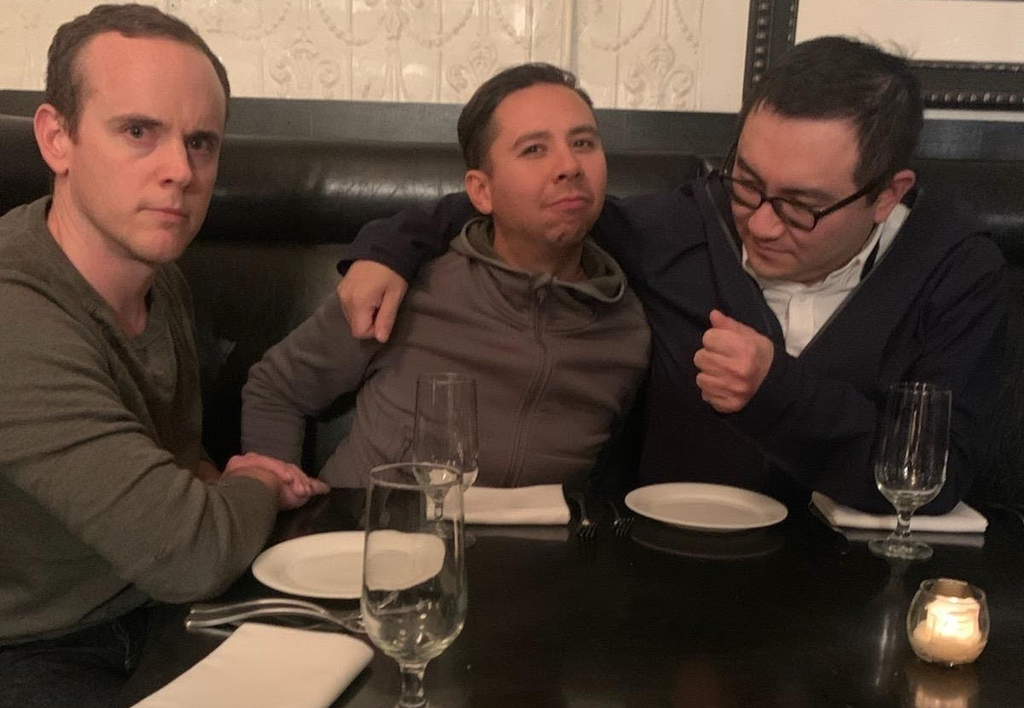

Ron. Adams (left)

Ron. Adams lives in Somerville Massachusetts. His writing covers the intersection of media, technology, and power. He discovered the work of Debord and The Situationists through his participation in Occupy Wall Street in 2011. His writing is online at https://0xadada.pub.